# Análise dos Fatores Influenciadores no Clima de Segurança do Paciente em Salas de Vacinação de Minas Gerais

## Métodos Estatísticos e Software

As análises estatísticas foram realizadas utilizando o software R (versão 4.3.2 ou superior) integrado ao ambiente RStudio. Os principais pacotes utilizados incluem tidyverse para manipulação de dados e criação de gráficos, readxl para importação de dados, gt e gtsummary para a elaboração de tabelas descritivas e de resultados de modelos estatísticos, skimr para estatísticas descritivas sumárias, e pacotes específicos para modelagem estatística como nnet (para regressão logística multinomial) ou MASS (para regressão logística ordinal), e lmtest e car para diagnósticos de modelos lineares.

## Carregamento de Pacotes e Dados

**Mostrar/Ocultar código da célula**

```r
# 1. Carregar Pacotes Essenciais
library(plyr)
library(tidyverse)    # Para manipulação de dados e gráficos (ggplot2, dplyr, etc.)
library(readxl)       # Para ler arquivos Excel
library(gt)           # Para tabelas formatadas de alta qualidade
library(gtsummary)    # Para tabelas de resumo e de modelos estatísticos
library(skimr)        # Para estatísticas descritivas rápidas
library(kableExtra)   # Para formatação adicional de tabelas kable
library(ggpubr)       # Para adicionar p-valores e outros elementos a gráficos ggplot2
library(rstatix)      # Para testes estatísticos e manipulação de resultados
library(car)          # Para diagnósticos de regressão (e.g., VIF, teste de Levene)
library(lmtest)       # Para testes em modelos lineares (e.g., Breusch-Pagan)
# Adicionar outros pacotes conforme necessário para análises específicas (e.g., nnet, MASS, sf, geobr)
library(sf)           # Para mapas
library(geobr)        # Para dados geográficos do Brasil

# Carregar funções auxiliares (se o arquivo existir e a função for necessária)
if (file.exists("scripts/funcoes_auxiliares.R")) {
  source("scripts/funcoes_auxiliares.R")
} else {
  # Definir a função limpar_nomes aqui se o arquivo não for encontrado, para evitar erro
  limpar_nomes <- function(nomes) {
    nomes_limpos <- stringr::str_to_lower(nomes)
    nomes_limpos <- iconv(nomes_limpos, from = "UTF-8", to = "ASCII//TRANSLIT")
    nomes_limpos <- stringr::str_replace_all(nomes_limpos, "[^a-z0-9 ]", "")
    nomes_limpos <- stringr::str_replace_all(nomes_limpos, "\\s+", " ")
    nomes_limpos <- stringr::str_trim(nomes_limpos)
    return(nomes_limpos)
  }
  warning("Arquivo 'scripts/funcoes_auxiliares.R' não encontrado. Usando definição interna de limpar_nomes().")
}

# 2. Definir Caminhos e Variáveis (ajuste conforme sua estrutura de projeto)
caminho_dados_processados <- "output/dados_mapeados_com_pontuacoes.xlsx" # Confirme este caminho
caminho_dados_limpos <- "output/dados_limpos_para_likert.xlsx"        # Caminho para os dados limpos (escala 1-5)
caminho_municipios_info <- "data/MUNICÍPIOS E SALAS DE VACINAÇÃO SELECIONADOS.xlsx" # Caminho para info completa dos municípios

# Nomes das variáveis chave (conforme fornecido anteriormente)
var_idade <- "idade_num"
var_sexo <- "Sexo"
var_cargo <- "Cargo na Atenção Primária à Saúde (APS) / Unidade Básica de Saúde (UBS)" # Removido crases externas
var_formacao <- "Formação" # Já corrigido
var_exp_aps_cat <- "Tempo de Experiência na Atenção Primária à Saúde_cat" # Removido crases externas
var_exp_vac_cat <- "Tempo de Experiência em Salas de Vacinação_cat" # Removido crases externas
var_exp_total_cat <- "Tempo de Experiência Total como Profissional da Enfermagem...41_cat" # Removido crases externas
var_porte_ibge <- "PORTE_IBGE"
var_macrorregiao <- "MACRORREGIOES"
var_urs <- "URS"

var_clima_total <- "clima_seguranca_total"
var_class_clima <- "classificacao_clima"

vars_dominios <- c(
  "clima_trabalho_equipe", "clima_seguranca", "satisfacao_trabalho",
  "percepcao_estresse", "percepcao_gestao", "condicoes_trabalho"
)

# 3. Carregar Dados Processados
dados_analise <- read_excel(caminho_dados_processados)
dados_likert_input <- read_excel(caminho_dados_limpos) # Carregar dados limpos para Likert

# 3.5 Carregar Informações Completas dos Municípios (para mapas)
tryCatch({
  df_municipios_amostra_qmd <- read_excel(caminho_municipios_info, sheet = "AMOSTRA", skip = 4)
  df_municipios_info_qmd <- df_municipios_amostra_qmd %>%
    rename(
      MUNICIPIO_RAW = 6, # Nome original com código
      MACRORREGIOES = 4,
      # Adicionar outros se precisar (URS, PORTE_IBGE...)
    ) %>%
    select(MUNICIPIO_RAW, MACRORREGIOES) %>%
    mutate(
      MUNICIPIO = str_replace(MUNICIPIO_RAW, "^[0-9]+-", ""), # Remover código
      Municipio_join = limpar_nomes(MUNICIPIO), # Limpar para junção
      MACRORREGIOES = str_trim(MACRORREGIOES)
    ) %>%
    distinct(Municipio_join, .keep_all = TRUE) # Manter apenas um por município limpo
  cat("Informações completas de municípios/macrorregiões carregadas para mapas.\n")
}, error = function(e) {
  warning(paste("Erro ao carregar informações completas de municípios:", e$message, ". Mapas podem não ser gerados corretamente."))
  df_municipios_info_qmd <- NULL # Define como NULL se houver erro
})
## Informações completas de municípios/macrorregiões carregadas para mapas.


# Converter colunas categóricas relevantes para fator, se necessário, para garantir a ordem correta em tabelas e gráficos
# Exemplo: Ordenar 'classificacao_clima'
if (var_class_clima %in% names(dados_analise)) {
  dados_analise[[var_class_clima]] <- factor(dados_analise[[var_class_clima]],
                                             levels = c("Negativo", "Neutro", "Positivo"))
}

# Exemplo: Ordenar 'PORTE_IBGE'
if (var_porte_ibge %in% names(dados_analise)) {
  dados_analise[[var_porte_ibge]] <- factor(dados_analise[[var_porte_ibge]],
                                             levels = c("Pequeno Porte", "Médio Porte", "Grande Porte")) # Ajustado para "Pequeno Porte", "Médio Porte", "Grande Porte"
}


# Visualizar as primeiras linhas e a estrutura dos dados carregados
# glimpse(dados_analise) # Descomente para verificar no console ao renderizar
# head(dados_analise)    # Descomente para verificar no console ao renderizar

cat("Dados carregados. Número de observações:", nrow(dados_analise), "\n")
## Dados carregados. Número de observações: 647
cat("Número de colunas:", ncol(dados_analise), "\n")
## Número de colunas: 75
```

# 3. Resultados

Nesta seção, são apresentados os resultados da análise estatística, iniciando pela caracterização da amostra de profissionais e do contexto das unidades de saúde. Em seguida, detalha-se a avaliação do clima de segurança do paciente, incluindo a distribuição das respostas aos itens do questionário, os escores globais e por domínio, e as análises univariada e multivariada dos fatores associados.

## 3.1. Caracterização da Amostra e do Contexto

A amostra final do estudo foi composta por 647 profissionais de enfermagem atuantes em salas de vacinação de Minas Gerais. A análise descritiva a seguir foca nas principais variáveis sociodemográficas, profissionais e contextuais.

### 3.1.1. Idade dos Profissionais

As estatísticas descritivas para a idade dos profissionais são apresentadas abaixo:

Tabela 2: Estatísticas descritivas da Idade dos profissionais (anos).

Estatísticas descritivas da Idade (anos)

| N | Média | Desvio Padrão | Mínimo | P25 | Mediana | P75 | Máximo |
| --- | --- | --- | --- | --- | --- | --- | --- |
| 647 | 39.9 | 9.4 | 19 | 33 | 40 | 46 | 66 |

A distribuição das idades pode ser visualizada no histograma abaixo (Figura Figura 1).

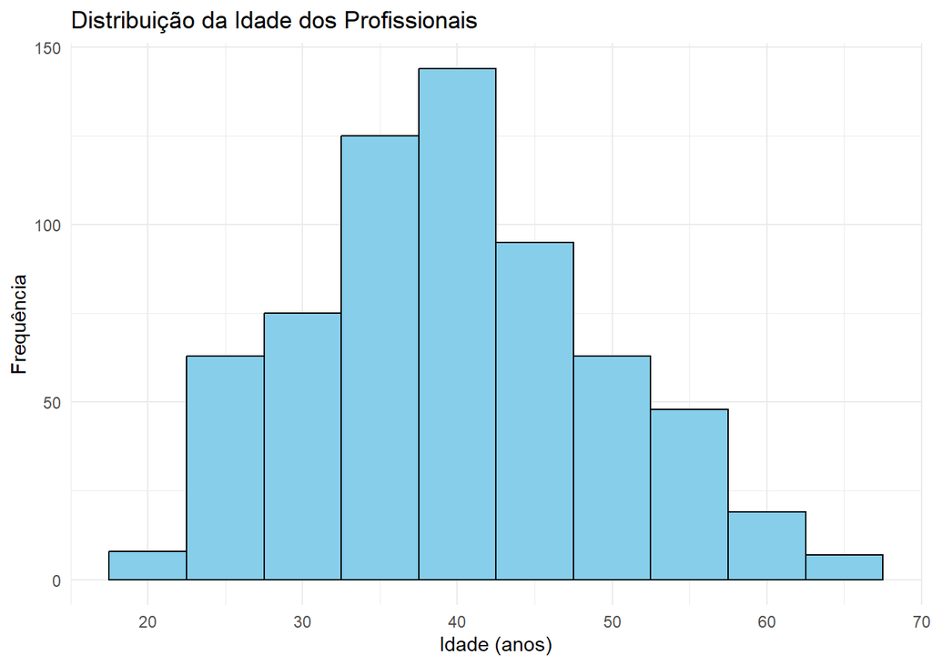

Figura 1: Histograma da distribuição da Idade dos profissionais.

A idade média dos 647 profissionais da amostra é de aproximadamente 39,9 anos, com um desvio padrão de 9,4 anos. A mediana da idade é de 40 anos, indicando que metade dos profissionais tem até 40 anos. As idades variam de 19 a 66 anos, com 50% dos profissionais concentrando-se entre 33 e 46 anos (intervalo interquartil). O histograma (Figura 1) sugere uma distribuição unimodal, com a maior concentração de profissionais na faixa etária entre 35 e 45 anos. Há uma leve assimetria, com uma cauda um pouco mais longa para idades mais elevadas.

### 3.1.2. Características Categóricas

A Tabela Tabela 3 resume as características categóricas selecionadas dos profissionais e do contexto de trabalho.

**Configuração - Variáveis Categóricas**

```r
# Variáveis categóricas selecionadas
vars_categoricas_selecionadas <- c(
  var_sexo,
  var_cargo,
  var_formacao,
  var_exp_total_cat,
  var_exp_aps_cat,
  var_exp_vac_cat
)

# Filtrar para variáveis que existem em dados_analise
vars_categoricas_existentes <- intersect(vars_categoricas_selecionadas, names(dados_analise))

# Definir rótulos APENAS para as variáveis existentes
rotulos_categoricos <- list(
  Sexo ~ "Sexo",
  `Cargo na Atenção Primária à Saúde (APS) / Unidade Básica de Saúde (UBS)` ~ "Cargo na APS/UBS",
  Formação ~ "Formação",
  `Tempo de Experiência Total como Profissional da Enfermagem...41_cat` ~ "Tempo de Exp. Total Enfermagem",
  `Tempo de Experiência na Atenção Primária à Saúde_cat` ~ "Tempo de Exp. na APS",
  `Tempo de Experiência em Salas de Vacinação_cat` ~ "Tempo de Exp. em Sala de Vacinação"
)

# Manter apenas rótulos para variáveis existentes
rotulos_categoricos_final <- rotulos_categoricos[names(rotulos_categoricos) %in% vars_categoricas_existentes]

# Ordenar níveis de fatores para tempo de experiência (se existirem)
levels_experiencia <- c("Menos de 6 meses", "de 6 meses a 1 ano", "de 1 a 3 anos",
                        "de 3 a 5 anos", "de 5 a 10 anos", "de 10 a 15 anos",
                        "de 15 a 20 anos", "Mais de 20 anos", "Não aplicável")

if (var_exp_total_cat %in% vars_categoricas_existentes) {
  dados_analise[[var_exp_total_cat]] <- factor(dados_analise[[var_exp_total_cat]], levels = intersect(levels_experiencia, unique(dados_analise[[var_exp_total_cat]])))
}
if (var_exp_aps_cat %in% vars_categoricas_existentes) {
  dados_analise[[var_exp_aps_cat]] <- factor(dados_analise[[var_exp_aps_cat]], levels = intersect(levels_experiencia, unique(dados_analise[[var_exp_aps_cat]])))
}
if (var_exp_vac_cat %in% vars_categoricas_existentes) {
  dados_analise[[var_exp_vac_cat]] <- factor(dados_analise[[var_exp_vac_cat]], levels = intersect(levels_experiencia, unique(dados_analise[[var_exp_vac_cat]])))
}
# Adicione outras ordenações se necessário (Formação, Cargo etc.)
```

Tabela 3: Distribuição das características categóricas selecionadas (N=647).

**Tabela 3.1: Distribuição das Características Categóricas Selecionadas**

| **Característica** | **N = 647**<sup>1</sup> |
| --- | --- |
| Sexo |  |
| Feminino | 594 (91.8%) |
| Masculino | 53 (8.2%) |
| Cargo na Atenção Primária à Saúde (APS) / Unidade Básica de Saúde (UBS) |  |
| Auxiliar de Enfermagem | 33 (5.1%) |
| Enfermeiro(a) | 266 (41.1%) |
| Técnico em Enfermagem | 348 (53.8%) |
| Formação |  |
| Doutorado | 1 (0.2%) |
| Ensino Médio Completo | 14 (2.2%) |
| Ensino Técnico | 322 (49.8%) |
| Especialização Lato Sensu | 147 (22.7%) |
| Especialização nível Residência | 7 (1.1%) |
| Graduação | 152 (23.5%) |
| Mestrado | 4 (0.6%) |
| Tempo de Experiência Total como Profissional da Enfermagem...41_cat |  |
| de 6 meses a 1 ano | 23 (3.6%) |
| de 1 a 3 anos | 101 (15.6%) |
| de 3 a 5 anos | 80 (12.4%) |
| de 5 a 10 anos | 138 (21.4%) |
| de 10 a 15 anos | 112 (17.3%) |
| de 15 a 20 anos | 93 (14.4%) |
| Mais de 20 anos | 99 (15.3%) |
| Não informado/Ausente | 1 |
| Tempo de Experiência na Atenção Primária à Saúde_cat |  |
| de 6 meses a 1 ano | 19 (2.9%) |
| de 1 a 3 anos | 95 (14.7%) |
| de 3 a 5 anos | 87 (13.4%) |
| de 5 a 10 anos | 130 (20.1%) |
| de 10 a 15 anos | 111 (17.2%) |
| de 15 a 20 anos | 98 (15.1%) |
| Mais de 20 anos | 107 (16.5%) |
| Tempo de Experiência em Salas de Vacinação_cat |  |
| de 6 meses a 1 ano | 34 (5.3%) |
| de 1 a 3 anos | 144 (22.3%) |
| de 3 a 5 anos | 94 (14.5%) |
| de 5 a 10 anos | 159 (24.6%) |
| de 10 a 15 anos | 76 (11.7%) |
| de 15 a 20 anos | 75 (11.6%) |
| Mais de 20 anos | 65 (10.0%) |

<sup>1</sup> n (%)

A Tabela Tabela 3 detalha o perfil dos participantes. Observa-se uma predominância do sexo feminino (91,8%). Quanto ao cargo, a maioria dos profissionais atua como Técnico em Enfermagem (53,8%) ou Enfermeiro(a) (41,1%), com uma pequena parcela de Auxiliares de Enfermagem (5,1%). A formação mais comum é o Ensino Técnico (49,8%), seguida pela Graduação (23,5%) e Especialização Lato Sensu (22,7%). Em relação ao tempo de experiência total na enfermagem, a distribuição é relativamente equilibrada entre as faixas, com destaque para o intervalo de 5 a 10 anos (21,4%). Padrão semelhante ocorre para o tempo de experiência na APS. Já o tempo de experiência específico em salas de vacinação concentra-se mais nas faixas iniciais, especialmente de 5 a 10 anos (24,6%) e de 1 a 3 anos (22,3%).

## 3.2. Análise do Clima de Segurança do Paciente

### 3.2.1. Distribuição das Respostas aos Itens do Questionário (Escala Likert)

A percepção dos profissionais sobre os diferentes aspectos do clima de segurança foi inicialmente avaliada por meio da distribuição das respostas aos 36 itens do questionário SAQ-SF. Os itens são agrupados em seis domínios principais. É importante notar que algumas questões são formuladas de maneira negativa (e.g., “É difícil falar abertamente…”). Para estas, uma maior concordância indica uma percepção mais negativa do clima. Nos gráficos a seguir, essas questões são identificadas com o prefixo “NEG:” e suas respostas devem ser interpretadas considerando essa inversão de sentido.

As questões com formulação negativa, cujas respostas foram invertidas para o cálculo dos escores (onde maior pontuação significa melhor percepção), mas que nos gráficos de Likert são apresentadas com sua concordância original, são: **Q2, Q11, Q20, Q21, Q22, Q23 e Q36**.

**Preparar dados e função para gráficos Likert**

```r
# Este chunk é o mesmo da resposta anterior, garantindo que os dados Likert sejam preparados.
# Vou assumir que ele foi executado corretamente e os objetos likert_*-qmd e data_likert_*-qmd existem.
# Se houve erro aqui, os plots abaixo não funcionarão.

# Carregar pacotes adicionais se ainda não carregados na sessão
library(likert)
library(RColorBrewer)
library(patchwork)
library(stringr)

# Definir os níveis da escala Likert em português
likert_levels <- c("Discordo Totalmente", "Discordo Pouco", "Neutro", "Concordo Pouco", "Concordo Totalmente")

# Nomes das colunas das questões originais no dataframe 'dados_analise'
perguntas_invertidas_base_nomes_originais <- c(
  "2. É difícil falar abertamente se eu percebo um problema com o cuidado ao paciente relacionado a vacinação",
  "11. Nesta unidade, é difícil discutir sobre erros",
  "20. Quando minha carga de trabalho é excessiva, meu desempenho é prejudicado",
  "21. Eu sou menos eficiente no trabalho quando estou cansado (a)",
  "22. Eu tenho maior probabilidade de cometer erros em situações tensas ou hostis",
  "23. O cansaço prejudica meu desempenho durante situações de stress (ex: interrupções, inquietude do vacinado, choro)",
  "36. Falhas na comunicação que levam a atrasos no atendimento são comuns"
)

# Função para preparar os dados para o pacote likert
prepare_likert_data_qmd <- function(df, columns_list, inverted_list_original_names) {
  missing_cols <- setdiff(columns_list, names(df))
  if (length(missing_cols) > 0) {
    stop(paste("As seguintes colunas não foram encontradas no dataframe:", paste(missing_cols, collapse=", ")))
  }
  df_subset <- df %>% select(all_of(columns_list))

  new_colnames <- sapply(columns_list, function(col_name) {
    if (col_name %in% inverted_list_original_names) {
      num_pergunta <- stringr::str_extract(col_name, "^[0-9]+\\.")
      texto_pergunta <- stringr::str_replace(col_name, "^[0-9]+\\.\\s*", "")
      return(paste0(num_pergunta, " NEG: ", texto_pergunta))
    } else {
      return(col_name)
    }
  })
  colnames(df_subset) <- new_colnames

  df_likert <- df_subset %>%
    mutate(across(everything(), ~factor(as.integer(.x), levels = 1:5, labels = likert_levels, ordered = TRUE)))
  return(as.data.frame(df_likert))
}

# Definir colunas por domínio
cols_clima_equipe_orig <- c("1. As sugestões do (a) enfermeiro (a) são bem recebidas na sala de vacinação", "2. É difícil falar abertamente se eu percebo um problema com o cuidado ao paciente relacionado a vacinação", "3. Em relação à vacinação, as discordâncias são resolvidas de modo apropriado (ex: não quem está certo, mas o que é melhor para o paciente)","4. Eu tenho o apoio que necessito de outros membros da equipe para assistência aos pacientes na sala e vacinação", "5. É fácil para mim, que atuo na vacinação, fazer perguntas quando existe algo que eu não entendo", "6. A equipe de enfermagem daqui trabalha junto como uma equipe bem coordenada")
cols_clima_seguranca_orig <- c("7. Eu me sentiria seguro (a) se fosse vacinado (a) aqui como paciente", "8. Erros são tratados de maneira apropriada pela equipe", "9. Eu conheço os meios adequados para encaminhar as questões relacionadas à segurança do paciente nesta unidade", "10. Eu recebo retorno apropriado sobre meu desempenho", "11. Nesta unidade, é difícil discutir sobre erros", "12. Sou encorajado (a) por meus colegas a informar qualquer preocupação que eu possa ter quanto à segurança em sala de vacinação", "13. A cultura de segurança em vacinação torna fácil aprender com os erros dos outros")
cols_satisfacao_orig <- c("15. Eu gosto de trabalhar com vacinação", "16. Trabalhar aqui é como fazer parte de uma grande família", "17. A sala de vacinação é um bom lugar para trabalhar", "18. Eu me orgulho de trabalhar na vacinação", "19. O prestígio em trabalhar com vacinação é alto")
cols_estresse_orig <- c("20. Quando minha carga de trabalho é excessiva, meu desempenho é prejudicado", "21. Eu sou menos eficiente no trabalho quando estou cansado (a)", "22. Eu tenho maior probabilidade de cometer erros em situações tensas ou hostis", "23. O cansaço prejudica meu desempenho durante situações de stress (ex: interrupções, inquietude do vacinado, choro)")
cols_gestao_orig <- c("24. A coordenação apoia meus esforços diários", "25. A coordenação não compromete conscientemente a segurança do paciente", "26. A coordenação está fazendo um bom trabalho", "27. Profissionais problemáticos da equipe são tratados de maneira construtiva por nossa coordenação da unidade", "28. Recebo informações adequadas e oportunas sobre eventos que podem afetar o meu trabalho em sala de vacinação", "29. Na sala de vacinação, o número e a qualificação dos profissionais são suficientes para lidar com o número de pacientes")
cols_condicoes_orig <- c("30. Esta unidade faz um bom trabalho no treinamento de novos membros da equipe de vacinação", "31. Toda informação necessária para a vacinação está disponível rotineiramente para mim", "32. Estagiários da minha profissão são adequadamente supervisionados")

# Preparar os dados para cada domínio
data_likert_equipe_qmd <- prepare_likert_data_qmd(dados_likert_input, cols_clima_equipe_orig, perguntas_invertidas_base_nomes_originais)
data_likert_seguranca_qmd <- prepare_likert_data_qmd(dados_likert_input, cols_clima_seguranca_orig, perguntas_invertidas_base_nomes_originais)
data_likert_satisfacao_qmd <- prepare_likert_data_qmd(dados_likert_input, cols_satisfacao_orig, perguntas_invertidas_base_nomes_originais)
data_likert_estresse_qmd <- prepare_likert_data_qmd(dados_likert_input, cols_estresse_orig, perguntas_invertidas_base_nomes_originais)
data_likert_gestao_qmd <- prepare_likert_data_qmd(dados_likert_input, cols_gestao_orig, perguntas_invertidas_base_nomes_originais)
data_likert_condicoes_qmd <- prepare_likert_data_qmd(dados_likert_input, cols_condicoes_orig, perguntas_invertidas_base_nomes_originais)

# Criar objetos likert
likert_eq_qmd <- likert(data_likert_equipe_qmd)
likert_seg_qmd <- likert(data_likert_seguranca_qmd)
likert_sat_qmd <- likert(data_likert_satisfacao_qmd)
likert_est_qmd <- likert(data_likert_estresse_qmd)
likert_ges_qmd <- likert(data_likert_gestao_qmd)
likert_con_qmd <- likert(data_likert_condicoes_qmd)

# Definir uma paleta de cores divergente personalizada
cores_base_rdbu_qmd <- RColorBrewer::brewer.pal(5, "RdBu")
# Ajuste para ter 5 cores, não 9. Se o anterior era `cores_base_rdbu_qmd[c(1,2,5,4,3)]` ou algo assim, precisa reavaliar.
# Se a intenção é pegar as extremas e a do meio:
# cores_personalizadas_qmd <- c(cores_base_rdbu_qmd[1], cores_base_rdbu_qmd[2], "grey80", cores_base_rdbu_qmd[4], cores_base_rdbu_qmd[5])
# Se o erro foi na duplicação:
cores_personalizadas_qmd <- c(cores_base_rdbu_qmd[1], cores_base_rdbu_qmd[2], "grey80", cores_base_rdbu_qmd[4], cores_base_rdbu_qmd[5])


# Função auxiliar para criar plots Likert
criar_plot_likert_qmd <- function(likert_obj, data_likert_df, titulo_plot,
                                  cores_lik,
                                  tamanho_titulo_plot = 14,
                                  tamanho_eixo_y = 11,  # Aumentado de 10
                                  tamanho_leg_texto = 11, # Aumentado de 10
                                  tamanho_leg_titulo = 13, # Aumentado de 12
                                  mostrar_legenda = TRUE,
                                  largura_wrap_labels = 70,
                                  percent_text_size = 4) { # Aumentado de 3.5

  nomes_colunas_plot <- colnames(data_likert_df)
  labels_y_wrapped <- stringr::str_wrap(nomes_colunas_plot, width = largura_wrap_labels)

  p_final <- plot(likert_obj, centered = TRUE, center = 3, colors = cores_lik, group.order = nomes_colunas_plot,
                  plot.percents = TRUE,          # Mostrar porcentagens
                  plot.percent.low = TRUE,       # Mostrar % Discordo Totalmente
                  plot.percent.high = TRUE,      # Mostrar % Concordo Totalmente
                  plot.percent.neutral = FALSE,  # Ocultar % Neutro
                  percent.text.size = percent_text_size, # Usar argumento
                  percent.label = FALSE          # Ocultar o símbolo "%"
                  ) +
    ggtitle(titulo_plot) +
    scale_y_discrete(labels = labels_y_wrapped) +
    theme_minimal(base_size = 11) + # Aumentado base_size
    theme(
      plot.title = element_text(hjust = 0.5, size = tamanho_titulo_plot, face = "bold"),
      axis.text.y = element_text(size = tamanho_eixo_y, hjust = 1, margin = margin(t=0, r=5, b=0, l=0)),
      axis.title.x = element_blank(),
      axis.title.y = element_blank(),
      legend.text = element_text(size = tamanho_leg_texto),
      legend.title = element_text(size = tamanho_leg_titulo),
      panel.grid.major.y = element_blank(),
      panel.grid.minor.y = element_blank()
    )

  if (mostrar_legenda) {
    p_final <- p_final + guides(fill = guide_legend(title = "Nível de Concordância"))
  } else {
    p_final <- p_final + theme(legend.position = "none")
  }
  return(p_final)
}
```

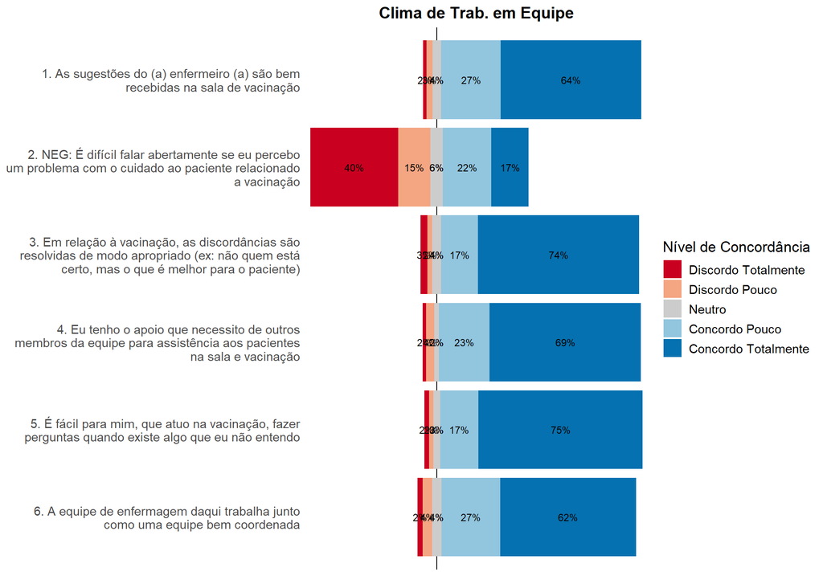

Figura 2: Distribuição das respostas: Clima de Trabalho em Equipe.

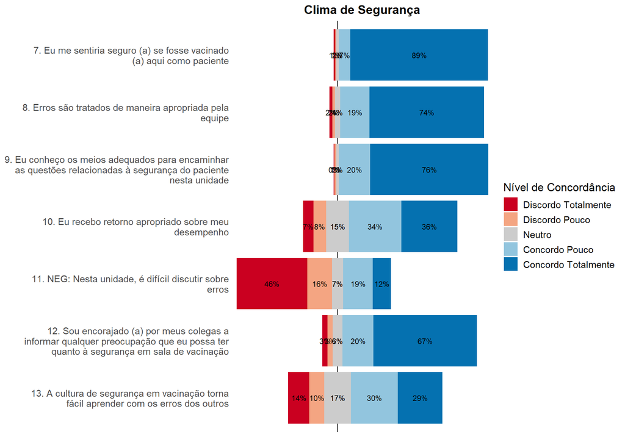

Figura 3: Distribuição das respostas: Clima de Segurança.

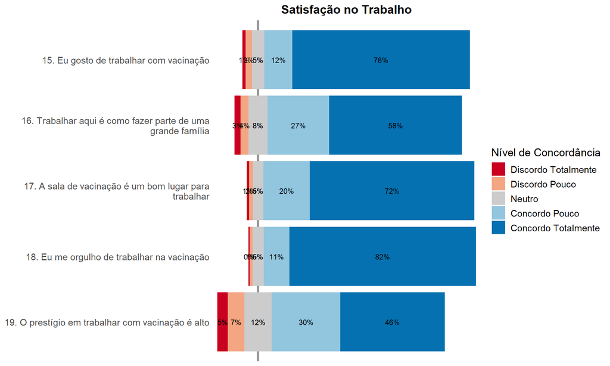

Figura 4: Distribuição das respostas: Satisfação no Trabalho.

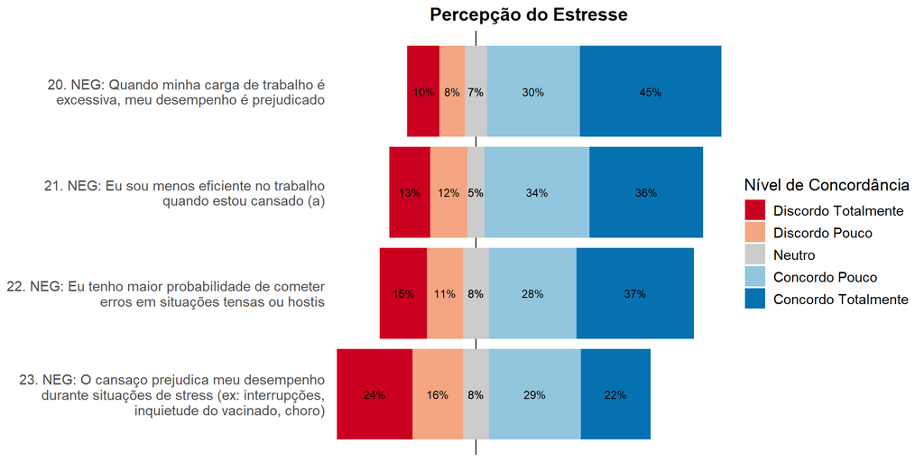

Figura 5: Distribuição das respostas: Percepção do Estresse.

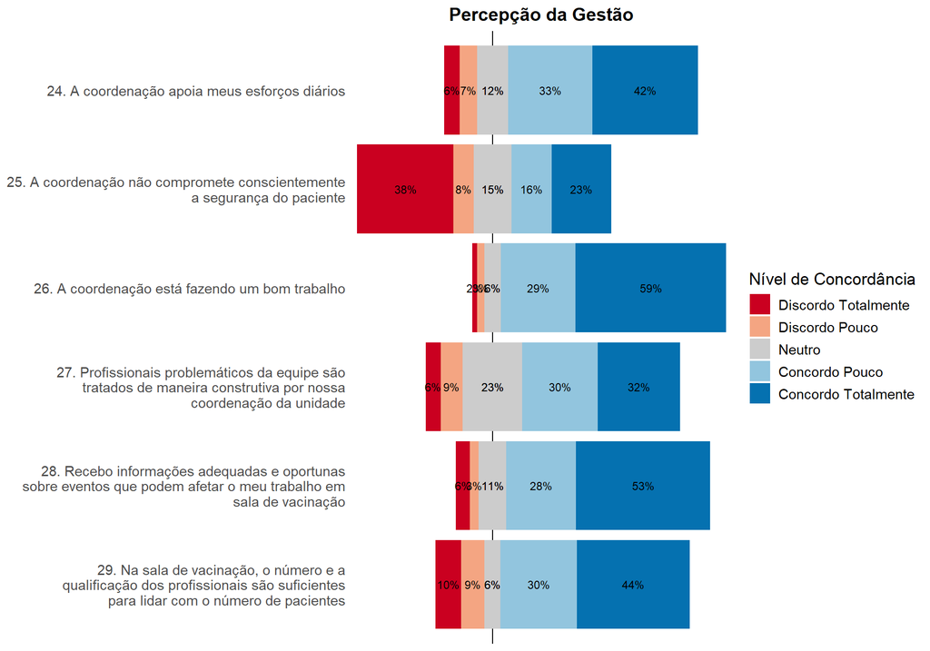

Figura 6: Distribuição das respostas: Percepção da Gestão.

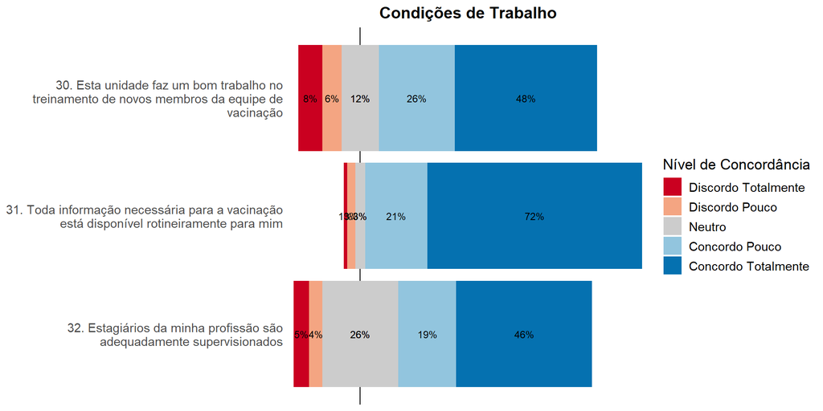

Figura 7: Distribuição das respostas: Condições de Trabalho.

As Figuras Figura 2, Figura 3, Figura 4, Figura 5, Figura 6 e Figura 7 ilustram a distribuição das respostas para cada item dos seis domínios do clima de segurança.

A análise detalhada das respostas aos itens do questionário SAQ-SF, agrupadas por domínio (Figuras Figura 2, Figura 3, Figura 4, Figura 5, Figura 6 e Figura 7), revela nuances importantes sobre o clima de segurança:

**Resumo da Percepção:** De forma geral, os profissionais demonstram alta satisfação com o trabalho e percebem um bom clima de equipe, sentindo-se seguros e apoiados pelos colegas. Contudo, existem barreiras importantes relacionadas à comunicação sobre erros, feedback, percepção sobre a gestão (especialmente em relação ao comprometimento com a segurança e adequação de pessoal), reconhecimento do impacto do estresse e problemas nas condições de trabalho (treinamento e supervisão de estagiários).

### 3.2.2. Escores dos Domínios do Clima de Segurança

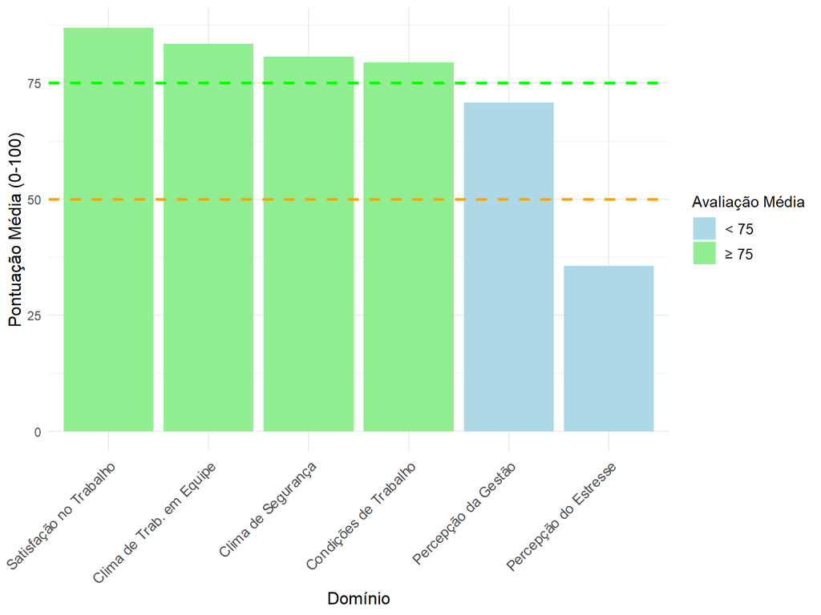

Figura 8: Pontuação Média por Domínio do Clima de Segurança.

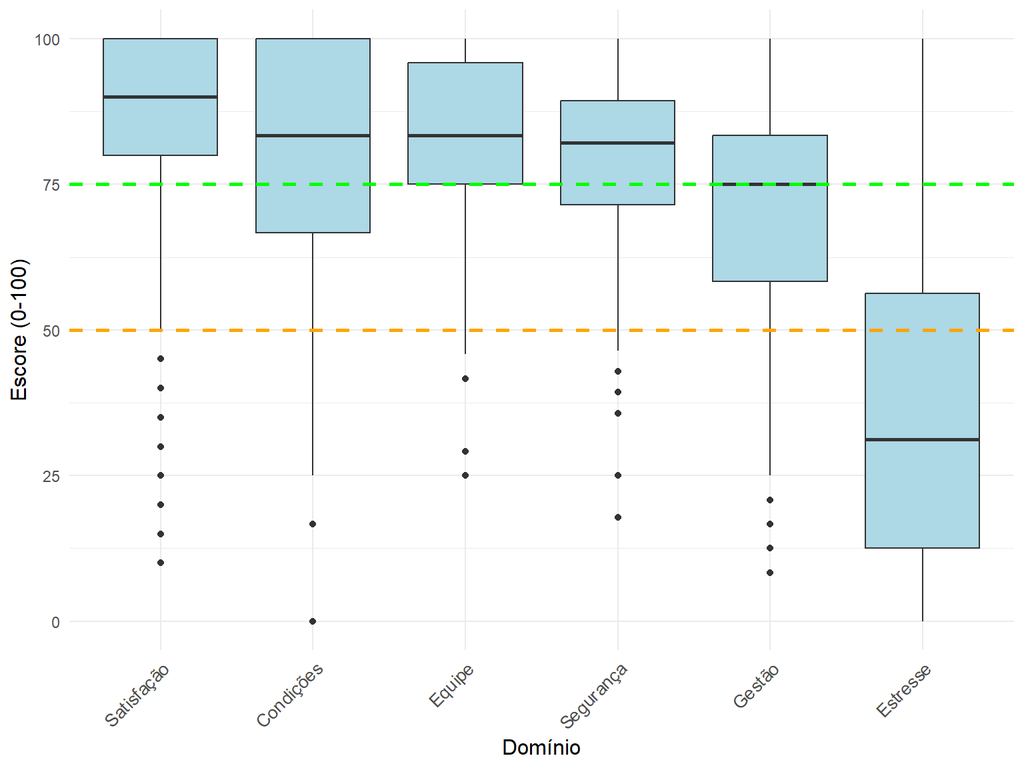

Figura 9: Distribuição dos Escores por Domínio do Clima de Segurança.

A análise consolidada dos escores (escala 0-100) para cada domínio revela o panorama geral da percepção do clima de segurança. O gráfico de barras (Figura 8) mostra que, na média, quatro domínios apresentam avaliação positiva (escore ≥ 75): Satisfação no Trabalho (média mais alta), Clima de Trabalho em Equipe, Clima de Segurança e Condições de Trabalho. A Percepção da Gestão apresenta uma média na faixa neutra (entre 50 e 75), enquanto a Percepção do Estresse tem a menor média, indicando uma avaliação média negativa (ressalta-se que, neste domínio, uma pontuação maior significa *menor* percepção de estresse, portanto a baixa média reflete uma *alta* percepção de estresse relatada).

## 3.3. Análise do Escore Geral do Clima de Segurança

Nesta seção, analisamos o escore geral do clima de segurança (`clima_seguranca_total`), que representa a média das 36 questões do SAQ-SF após o devido tratamento das escalas e inversão de itens negativos. Exploramos sua distribuição e como ele se relaciona com diferentes características sociodemográficas e profissionais.

### 3.3.1. Classificação Geral do Clima

Tabela 4: Distribuição da Classificação Geral do Clima de Segurança (N=647).

Distribuição da Classificação Geral do Clima de Segurança

| Classificação do Clima | N | Percentual (%) |
| --- | --- | --- |
| Positivo | 373 | 57.7 |
| Neutro | 257 | 39.7 |
| Negativo | 17 | 2.6 |

Dos 647 profissionais, a maioria (57,7%) percebe o clima de segurança como **Positivo**, enquanto 39,7% o classificam como **Neutro**. Uma pequena parcela (2,6%) tem uma percepção **Negativa**.

### 3.3.2. Estatísticas Descritivas do Escore Geral

Tabela 5: Estatísticas Descritivas do Escore Geral do Clima de Segurança (0-100).

Estatísticas Descritivas do Escore Geral do Clima de Segurança

| Estatística | Valor |
| --- | --- |
| Média | 75.0 |
| Desvio Padrão | 10.9 |
| Mediana | 77.1 |
| P25 | 68.8 |
| P75 | 83.3 |
| Mínimo | 27.1 |
| Máximo | 99.3 |

O escore geral do clima de segurança, numa escala de 0 a 100, apresentou uma **média de 75,0** e **mediana de 77,1**. Isso indica que, em geral, a percepção do clima de segurança tende a ser positiva. Os escores variaram de um mínimo de 27,1 a um máximo de 99,3, com 50% dos profissionais pontuando entre 68,8 (Percentil 25) e 83,3 (Percentil 75).

### 3.3.3. Escore Geral por Cargo

Tabela 6: Escore Geral do Clima de Segurança por Cargo.

| Cargo | N | Média | DP | Mediana | Positivo | % Positivo |
| --- | --- | --- | --- | --- | --- | --- |
| Auxiliar de Enfermagem | 33.0 | 77.1 | 10.0 | 79.2 | 21.0 | 63.6 |
| Técnico em Enfermagem | 348.0 | 76.0 | 11.1 | 77.8 | 212.0 | 60.9 |
| Enfermeiro(a) | 266.0 | 73.4 | 10.6 | 75.7 | 140.0 | 52.6 |

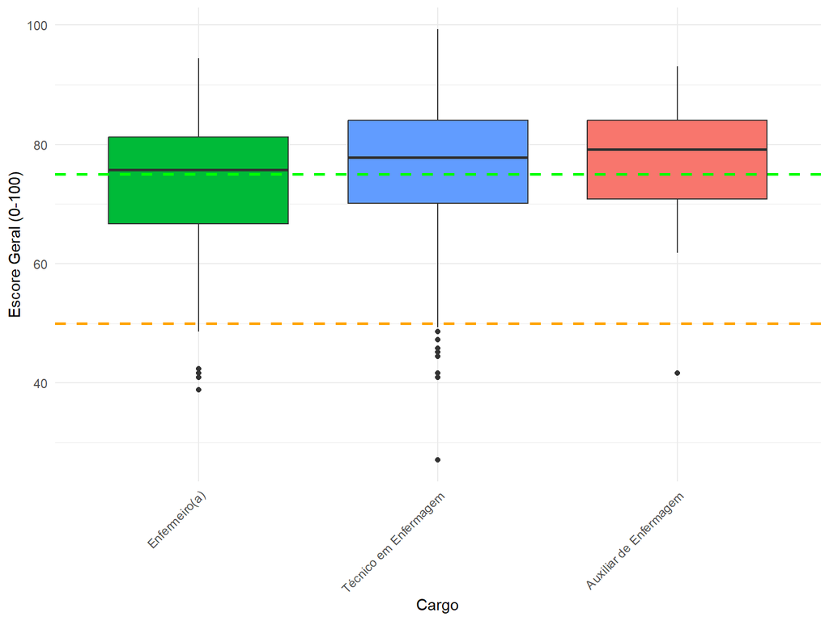

Figura 10: Distribuição do Escore Geral do Clima de Segurança por Cargo.

### 3.3.4. Escore Geral por Formação

Tabela 7: Escore Geral do Clima de Segurança por Formação.

| Formação | N | Média | DP | Mediana | Positivo | % Positivo |
| --- | --- | --- | --- | --- | --- | --- |
| Ensino Médio Completo | 14.0 | 76.8 | 12.5 | 81.2 | 9.0 | 64.3 |
| Ensino Técnico | 322.0 | 76.1 | 11.0 | 77.8 | 197.0 | 61.2 |
| Graduação | 152.0 | 74.8 | 10.8 | 77.1 | 88.0 | 57.9 |
| Especialização nível Residência | 7.0 | 74.0 | 13.0 | 79.2 | 5.0 | 71.4 |
| Especialização Lato Sensu | 147.0 | 72.6 | 10.3 | 73.6 | 72.0 | 49.0 |
| Mestrado | 4.0 | 71.7 | 8.5 | 74.0 | 2.0 | 50.0 |
| Doutorado | 1.0 | 71.5 | NA | 71.5 | 0.0 | 0.0 |

### 3.3.5. Escore Geral por Faixa Etária

Tabela 8: Escore Geral do Clima de Segurança por Faixa Etária.

| Faixa Etária | N | Média | DP | Mediana | Positivo | % Positivo |
| --- | --- | --- | --- | --- | --- | --- |
| < 20 anos | 4.0 | 76.2 | 4.8 | 77.4 | 3.0 | 75.0 |
| 20-30 anos | 112.0 | 74.9 | 11.4 | 77.8 | 68.0 | 60.7 |
| 31-40 anos | 237.0 | 73.9 | 11.9 | 77.1 | 131.0 | 55.3 |
| 41-50 anos | 202.0 | 75.1 | 9.8 | 75.7 | 112.0 | 55.4 |
| 51-60 anos | 81.0 | 76.7 | 10.1 | 77.1 | 48.0 | 59.3 |
| > 60 anos | 11.0 | 84.3 | 4.8 | 84.0 | 11.0 | 100.0 |

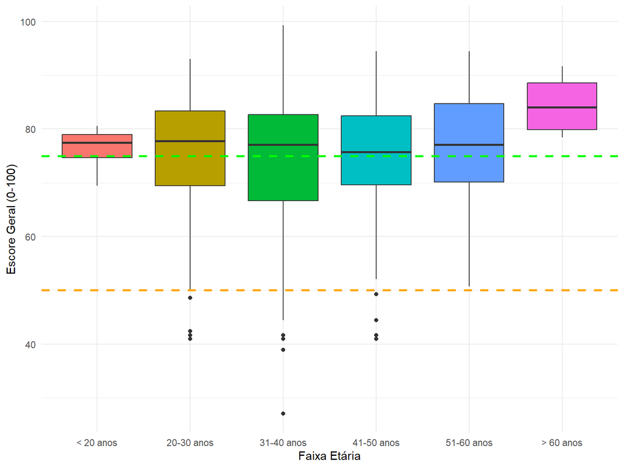

Figura 11: Distribuição do Escore Geral do Clima de Segurança por Faixa Etária.

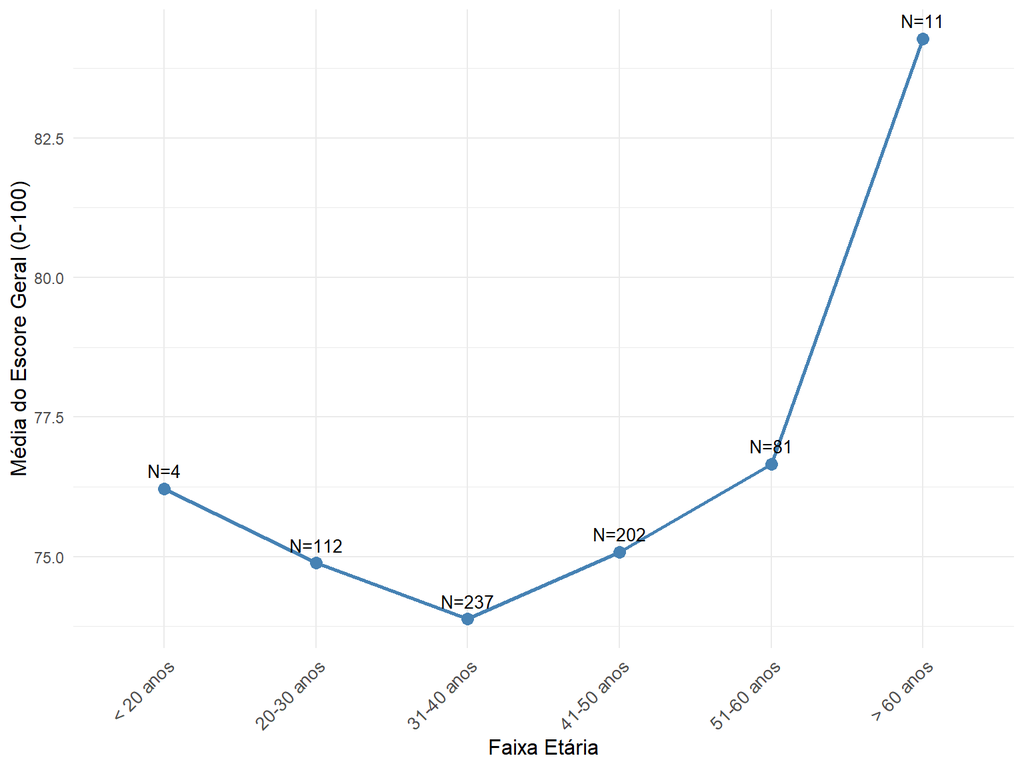

Figura 12: Média do Escore Geral do Clima de Segurança por Faixa Etária.

### 3.3.6. Escore Geral por Sexo

Tabela 9: Escore Geral do Clima de Segurança por Sexo.

| Sexo | N | Média | DP | Mediana | Positivo | % Positivo |
| --- | --- | --- | --- | --- | --- | --- |
| Feminino | 594.0 | 74.8 | 11.0 | 77.1 | 339.0 | 57.1 |
| Masculino | 53.0 | 76.9 | 9.7 | 77.8 | 34.0 | 64.2 |

Conforme a Tabela Tabela 9, profissionais do sexo masculino (N=53) apresentaram uma média de escore ligeiramente superior (76,9) em comparação com os do sexo feminino (N=594, média 74,8). O percentual de percepção positiva também foi maior entre os homens (64,2%) do que entre as mulheres (57,1%). Dada a grande disparidade no tamanho das amostras, mais análises seriam necessárias para determinar a significância dessa diferença.

### 3.3.7. Escore Geral por Porte do Município

Tabela 10: Escore Geral do Clima de Segurança por Porte do Município.

| Porte IBGE | N | Média | DP | Mediana | Positivo | % Positivo |
| --- | --- | --- | --- | --- | --- | --- |
| Pequeno Porte | 403.0 | 75.2 | 11.4 | 77.8 | 239.0 | 59.3 |
| Médio Porte | 73.0 | 74.3 | 9.9 | 75.0 | 37.0 | 50.7 |
| Grande Porte | 171.0 | 74.7 | 10.3 | 75.7 | 97.0 | 56.7 |

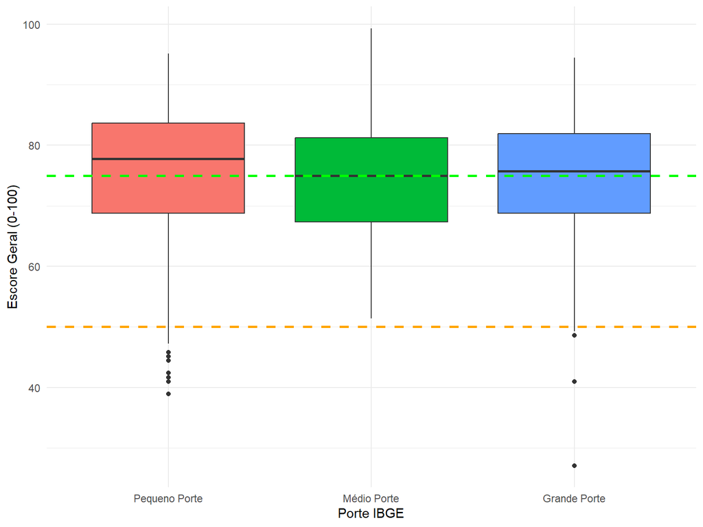

Figura 13: Distribuição do Escore Geral do Clima de Segurança por Porte do Município.

A Tabela Tabela 10 e a Figura Figura 13 indicam que a percepção do clima de segurança é similar entre os diferentes portes de município. Municípios de Pequeno Porte (N=403) tiveram a maior média (75,2), seguidos por Grande Porte (N=171, média 74,7) e Médio Porte (N=73, média 74,3). Os percentuais de clima positivo foram 59,3% (Pequeno), 50,7% (Médio) e 56,7% (Grande). Os boxplots mostram distribuições bastante sobrepostas, com medianas próximas, sugerindo pouca variação expressiva do escore geral em função do porte municipal.

### 3.3.8. Escore Geral por Macrorregião

Tabela 11: Escore Geral do Clima de Segurança por Macrorregião.

| Macrorregião | N | Média | DP | Mediana | Positivo | % Positivo |
| --- | --- | --- | --- | --- | --- | --- |
| CENTRO | 18.0 | 67.2 | 17.1 | 71.5 | 7.0 | 38.9 |
| CENTRO SUL | 69.0 | 74.0 | 13.1 | 75.7 | 39.0 | 56.5 |
| JEQUITINHONHA | 47.0 | 75.6 | 11.4 | 78.5 | 28.0 | 59.6 |
| LESTE | 29.0 | 73.7 | 11.0 | 75.0 | 15.0 | 51.7 |
| LESTE DO SUL | 17.0 | 70.7 | 10.0 | 70.8 | 6.0 | 35.3 |
| NORDESTE | 101.0 | 75.8 | 11.5 | 78.5 | 62.0 | 61.4 |
| NOROESTE | 2.0 | 75.7 | 5.9 | 75.7 | 1.0 | 50.0 |
| NORTE | 54.0 | 70.2 | 12.2 | 71.2 | 19.0 | 35.2 |
| OESTE | 214.0 | 75.5 | 8.8 | 76.4 | 126.0 | 58.9 |
| SUDESTE | 13.0 | 72.3 | 9.0 | 69.4 | 5.0 | 38.5 |
| SUL | 55.0 | 79.0 | 8.8 | 80.6 | 43.0 | 78.2 |
| TRIÂNGULO DO SUL | 9.0 | 85.1 | 6.7 | 84.7 | 9.0 | 100.0 |
| VALE DO AÇO | 19.0 | 78.1 | 8.2 | 79.2 | 13.0 | 68.4 |

A Tabela Tabela 11 mostra a percepção do clima de segurança entre as macrorregiões de saúde. Destacam-se positivamente as macrorregiões TRIÂNGULO DO SUL (N=9, Média=85,1, 100% Positivo), SUL (N=55, Média=79,0, 78,2% Positivo) e VALE DO AÇO (N=19, Média=78,1, 68,4% Positivo). Por outro lado, as macrorregiões CENTRO (N=18, Média=67,2, 38,9% Positivo), NORTE (N=54, Média=70,2, 35,2% Positivo) e LESTE DO SUL (N=17, Média=70,7, 35,3% Positivo) apresentaram as menores médias e percentuais de clima positivo. A macrorregião OESTE, com o maior número de respondentes (N=214), apresentou uma média de 75,5 (58,9% Positivo). É importante notar a variação no número de respondentes por macrorregião, com algumas (ex: NOROESTE, N=2) tendo uma representatividade muito pequena para generalizações.

### 3.3.9. Distribuição Espacial do Clima de Segurança

Para visualizar a distribuição geográfica da percepção do clima de segurança, foram gerados dois mapas: um com pontos nos centroides dos municípios participantes, coloridos pela média do escore e com tamanho proporcional ao número de respondentes, sobreposto a um mapa das macrorregiões da pesquisa; e um mapa coroplético colorindo as macrorregiões da pesquisa pela média do escore de clima de segurança.

**Gerar Mapa de Centroides Municipais**

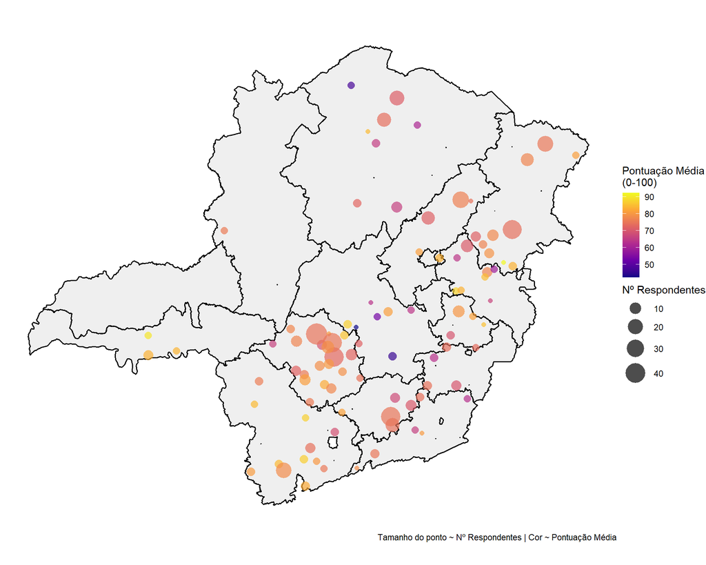

Figura 14: Clima de Segurança Médio e Nº de Respondentes por Município, sobre Fundo das Macrorregiões da Pesquisa.

```r
# Dependências: sf, geobr, dplyr, ggplot2, viridisLite (para scale_color_viridis_c)
# A função limpar_nomes() e o df_municipios_info_qmd devem estar disponíveis (carregados no setup)

if (!exists("mg_mun_qmd")) {
  mg_mun_qmd <- read_municipality(code_muni = "MG", year = 2020)
}

# Preparar dados para geometrias das Macrorregiões da Pesquisa (fundo)
# USA O DF COMPLETO CARREGADO NO SETUP (df_municipios_info_qmd)
sf_macrorregioes_dissolvidas_qmd <- NULL # Inicializa
if(!is.null(df_municipios_info_qmd)){
  mg_mun_com_macro_qmd <- mg_mun_qmd %>%
    mutate(Municipio_join = limpar_nomes(name_muni)) %>%
    left_join(df_municipios_info_qmd %>% select(Municipio_join, MACRORREGIOES), by = "Municipio_join")

  sf_macrorregioes_dissolvidas_qmd <- mg_mun_com_macro_qmd %>%
    filter(!is.na(MACRORREGIOES) & MACRORREGIOES != "") %>% # Filtrar NAs e vazios
    group_by(MACRORREGIOES) %>%
    summarize(
      geometry = st_union(geom),
      .groups = 'drop'
    ) %>%
    mutate(geometry = st_simplify(geometry, preserveTopology = TRUE, dTolerance = 500))
} else {
  cat("WARN: df_municipios_info_qmd não disponível. Fundo de macrorregiões não será gerado.\n")
  # Cria um objeto vazio para não dar erro no plot
  sf_macrorregioes_dissolvidas_qmd <- st_sf(MACRORREGIOES = character(), geometry = st_sfc(), crs = st_crs(mg_mun_qmd))
}

# Preparar dados para os centroides (continua usando dados_analise)
resumo_por_municipio_qmd <- dados_analise %>%
  group_by(!!sym("Município")) %>%
  summarise(
    media = mean(clima_seguranca_total, na.rm = TRUE),
    n = n(),
    .groups = 'drop'
  ) %>%
  mutate(Municipio_limpo = limpar_nomes(!!sym("Município")))

mg_mun_mapa_qmd_centroids <- mg_mun_qmd %>%
  mutate(Municipio_limpo = limpar_nomes(name_muni))

mg_map_data_qmd_centroids <- left_join(mg_mun_mapa_qmd_centroids,
                                       resumo_por_municipio_qmd %>% select(Municipio_limpo, `Município`, media, n),
                                       by = "Municipio_limpo")

mg_centroids_filtered_qmd <- mg_map_data_qmd_centroids %>%
  filter(!is.na(media)) %>%
  st_centroid()

# Plotar o mapa
if(nrow(mg_centroids_filtered_qmd) > 0){
  p_centroides <- ggplot()
  if(!is.null(sf_macrorregioes_dissolvidas_qmd) && nrow(sf_macrorregioes_dissolvidas_qmd) > 0) {
    p_centroides <- p_centroides + geom_sf(data = sf_macrorregioes_dissolvidas_qmd, fill = "grey92", color = "black", linewidth = 0.6, alpha = 0.8)
  }
  p_centroides <- p_centroides +
    geom_sf(data = mg_centroids_filtered_qmd, aes(size = n, color = media),
            shape = 16, alpha = 0.7) +
    scale_color_viridis_c(option = "plasma", name = "Pontuação Média\n(0-100)") +
    scale_size_continuous(name = "Nº Respondentes", range = c(2, 10)) +
    labs(caption = "Tamanho do ponto ~ Nº Respondentes | Cor ~ Pontuação Média") +
    theme_void() +
    theme(legend.position = "right")
  print(p_centroides)
} else {
  cat("Não há dados de centroides para plotar o mapa.\n")
}
```

**Gerar Mapa Coroplético por Macrorregião**

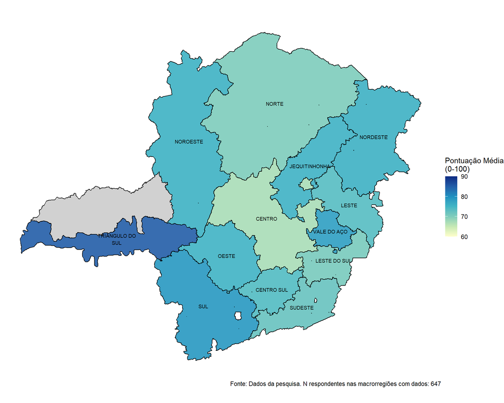

Figura 15: Clima de Segurança Médio por Macrorregião de Planejamento em MG.

```r
# Reutilizar sf_macrorregioes_dissolvidas_qmd (geometrias completas calculadas no chunk anterior)

# Calcular resumo por macrorregião a partir de dados_analise (para as cores)
resumo_por_macro_qmd_map <- dados_analise %>%
  filter(!is.na(!!sym(var_macrorregiao)) & !!sym(var_macrorregiao) != "") %>% # Filtrar NAs e vazios
  group_by(!!sym(var_macrorregiao)) %>%
  summarise(
    media = mean(clima_seguranca_total, na.rm = TRUE),
    n = n(),
    .groups = 'drop'
  ) %>%
  rename(MACRORREGIOES = !!sym(var_macrorregiao))

# Juntar geometrias completas com os dados de média da amostra
if(!is.null(sf_macrorregioes_dissolvidas_qmd) && nrow(sf_macrorregioes_dissolvidas_qmd) > 0) {
    map_data_macro_final_qmd <- sf_macrorregioes_dissolvidas_qmd %>%
      left_join(resumo_por_macro_qmd_map, by = "MACRORREGIOES")

    if(nrow(map_data_macro_final_qmd %>% filter(!is.na(media))) > 0) {
      min_media_map <- min(map_data_macro_final_qmd$media, na.rm = TRUE)
      max_media_map <- max(map_data_macro_final_qmd$media, na.rm = TRUE)

      ggplot() +
        geom_sf(data = map_data_macro_final_qmd, aes(fill = media), color = "black", linewidth = 0.5, alpha = 0.9) +
        scale_fill_distiller(
          palette = "YlGnBu",
          direction = 1,
          name = "Pontuação Média\n(0-100)",
          limits = c(floor(min_media_map/10)*10, ceiling(max_media_map/10)*10),
          na.value = "grey80" # Cor para macrorregiões sem respondentes
        ) +
        geom_sf_text(
          data = map_data_macro_final_qmd %>% filter(!is.na(media)), # Rotular apenas as com dados
          aes(label = str_wrap(MACRORREGIOES, width = 12)),
          size = 2.5,
          color = "black",
          fun.geometry = st_centroid,
          check_overlap = TRUE
        ) +
        labs(
          caption = paste0("Fonte: Dados da pesquisa. N respondentes nas macrorregiões com dados: ",
                           sum(resumo_por_macro_qmd_map$n[resumo_por_macro_qmd_map$MACRORREGIOES %in% (map_data_macro_final_qmd %>% filter(!is.na(media)) %>% pull(MACRORREGIOES))], na.rm = TRUE))
        ) +
        theme_void() +
        theme(legend.position = "right",
              panel.background = element_rect(fill = "white", colour = "white"))
    } else {
      cat("Não há dados de macrorregiões com média para plotar o mapa coroplético.\n")
    }
} else {
  cat("Geometrias das macrorregiões não disponíveis para o mapa coroplético.\n")
}
```

O mapa de centroides (Figura 14) permite visualizar a distribuição dos respondentes e a pontuação média do clima em cada município participante, sobreposto às macrorregiões de planejamento. Observa-se uma concentração de respondentes (pontos maiores) em certas áreas, como a macrorregião OESTE. As cores dos pontos indicam a variabilidade da pontuação média municipal, com tons mais quentes (amarelo/laranja) representando escores mais altos e tons mais frios (roxo) indicando escores mais baixos. Há uma predominância de cores mais quentes, alinhada com a média geral positiva, mas com pontos mais frios dispersos, sugerindo heterogeneidade local.

### 3.3.10. Escore Geral por Porte do Município e Cargo

Tabela 12: Escore Geral do Clima de Segurança por Porte do Município e Cargo.

| Porte IBGE | Cargo | N | Média | DP | Mediana | Positivo | % Positivo |
| --- | --- | --- | --- | --- | --- | --- | --- |
| Pequeno Porte | Auxiliar de Enfermagem | 25.0 | 77.6 | 10.8 | 79.2 | 16.0 | 64.0 |
| Pequeno Porte | Enfermeiro(a) | 163.0 | 73.7 | 11.3 | 77.1 | 91.0 | 55.8 |
| Pequeno Porte | Técnico em Enfermagem | 215.0 | 76.0 | 11.4 | 77.8 | 132.0 | 61.4 |
| Médio Porte | Auxiliar de Enfermagem | 1.0 | 75.0 | NA | 75.0 | 1.0 | 100.0 |
| Médio Porte | Enfermeiro(a) | 34.0 | 70.6 | 9.3 | 71.5 | 11.0 | 32.4 |
| Médio Porte | Técnico em Enfermagem | 38.0 | 77.6 | 9.5 | 78.1 | 25.0 | 65.8 |
| Grande Porte | Auxiliar de Enfermagem | 7.0 | 75.5 | 7.6 | 75.7 | 4.0 | 57.1 |
| Grande Porte | Enfermeiro(a) | 69.0 | 73.9 | 9.2 | 75.0 | 38.0 | 55.1 |
| Grande Porte | Técnico em Enfermagem | 95.0 | 75.3 | 11.3 | 77.1 | 55.0 | 57.9 |

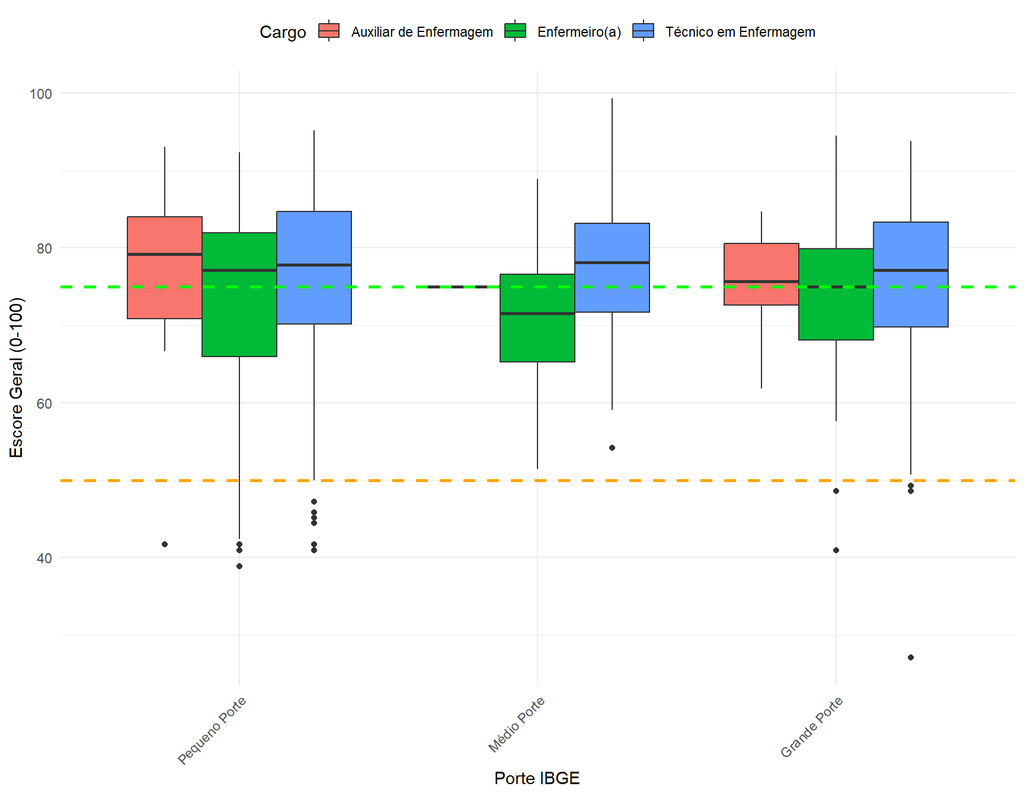

Figura 16: Distribuição do Escore Geral por Porte do Município e Cargo.

# 4. Análise Univariada dos Fatores Associados ao Clima de Segurança

Nesta seção, investigamos a associação entre as características sociodemográficas, profissionais e contextuais e o escore geral do clima de segurança do paciente (`clima_seguranca_total`). Foram aplicados testes de hipóteses para verificar se existem diferenças estatisticamente significativas nas médias ou medianas do escore entre os diferentes grupos ou se há correlação com variáveis contínuas. Adotou-se um nível de significância de p < 0,05.

**Configurações e Funções Auxiliares para Análise Univariada**

```r
# Opção para evitar notação científica nos p-valores
options(scipen = 999)

# Função auxiliar para formatar p-valores
formatar_p <- function(p_valor) {
  if (is.na(p_valor)) return("NA")
  if (p_valor < 0.001) return("< 0,001")
  if (p_valor < 0.01) return(formatC(p_valor, format = "f", digits = 4))
  return(formatC(p_valor, format = "f", digits = 4)) # Arredonda para 4 casas se >= 0.01
}

# Função SIMPLIFICADA para realizar APENAS o teste de Kruskal-Wallis
# Retorna uma lista com o p-valor e uma mensagem textual
analise_kruskal <- function(data, formula) {
  var_indep_name <- all.vars(formula)[2] # Pega o nome da variável independente
  var_dep_name <- all.vars(formula)[1]   # Pega o nome da variável dependente

  # Verificar se as variáveis existem
  if (!var_indep_name %in% names(data) || !var_dep_name %in% names(data)) {
     return(list(p_value = NA, resultado_texto = "Variável dependente ou independente não encontrada."))
  }

  # Filtrar NAs nas variáveis da fórmula para contagem de níveis e grupos
  # Ensure dplyr is loaded or use data.frame specific functions if not using tidyverse here
  # For safety, assuming data is a data.frame and using base R style for filtering if dplyr isn't guaranteed
  cols_to_check <- c(var_dep_name, var_indep_name)
  data_complete_cases <- data[complete.cases(data[, cols_to_check]), ]


  # Verificar se a variável independente tem pelo menos 2 níveis com dados
  n_levels <- length(unique(data_complete_cases[[var_indep_name]]))
  if (n_levels < 2) {
    return(list(p_value = NA, resultado_texto = paste0("Variável independente '", var_indep_name, "' com menos de 2 níveis válidos após remover NAs.")))
  }

  # Verificar se há pelo menos 2 grupos com mais de 1 observação
  group_counts <- table(data_complete_cases[[var_indep_name]])
  valid_groups <- sum(group_counts > 1)
  if (valid_groups < 2) {
    return(list(p_value = NA, resultado_texto = paste0("Menos de 2 grupos com observações suficientes para o teste em '", var_indep_name,"' após remover NAs.")))
  }

  # Realizar teste Kruskal-Wallis
  kw_test <- tryCatch({
    kruskal.test(formula, data = data) # kruskal.test handles NAs by default (listwise deletion based on formula)
  }, error = function(e) {
    warning(paste("Erro no Kruskal-Wallis para", var_indep_name, ":", e$message))
    return(NULL)
  })

  if (is.null(kw_test)) {
    return(list(p_value = NA, resultado_texto = "Erro ao executar Kruskal-Wallis."))
  }

  p_kw <- kw_test$p.value
  resultado <- paste0("Teste de Kruskal-Wallis: p = ", formatar_p(p_kw), ".")

  if (p_kw < 0.05) {
    resultado <- paste0(resultado, " Diferença estatisticamente significativa encontrada entre os grupos.")
  } else {
    resultado <- paste0(resultado, " Não foi encontrada diferença estatisticamente significativa entre os grupos.")
  }

  return(list(p_value = p_kw, resultado_texto = resultado))
}

# Função para realizar teste de Mann-Whitney (permanece a mesma)
analise_mann_whitney <- function(data, var_outcome, var_group) {
  # Limpar nomes de variáveis
  var_outcome_clean <- trimws(gsub("`", "", var_outcome))
  var_group_clean <- trimws(gsub("`", "", var_group))

  # Verificar se as variáveis existem no dataframe
  if (!var_outcome_clean %in% names(data) || !var_group_clean %in% names(data)) {
    return(paste0("Uma ou ambas as variáveis não foram encontradas no dataframe: ",
                  var_outcome_clean, ", ", var_group_clean))
  }

  # Verificar níveis da variável independente
  # Ensure dplyr is loaded for this syntax or adapt
  data_filtered_mw <- data[!is.na(data[[var_group_clean]]) & !is.na(data[[var_outcome_clean]]), ]
  levels_info <- unique(data_filtered_mw[[var_group_clean]])

  if (length(levels_info) != 2) {
    return(paste0("Variável independente '", var_group_clean, "' não possui exatamente 2 níveis válidos após remover NAs."))
  }

  # Verificar observações por grupo
  group_counts_mw <- as.data.frame(table(data_filtered_mw[[var_group_clean]]))

  if (any(group_counts_mw$Freq < 2)) { # Check Freq column from table
    return(paste0("Número insuficiente de observações em um ou ambos os grupos para '", var_group_clean, "' após remover NAs."))
  }

  # Construir a fórmula usando paste0 e as.formula (método que funcionou)
  formula_str <- paste0("`",var_outcome_clean, "` ~ `", var_group_clean, "`") # Ensure backticks for safety
  formula_obj <- as.formula(formula_str)

  # Executar Mann-Whitney
  mw_result <- tryCatch({
    wilcox.test(formula_obj, data = data) # wilcox.test handles NAs based on formula
  }, error = function(e) {
    message <- paste("Erro no Mann-Whitney para", var_group_clean, ":", e$message)
    warning(message)
    return(NULL)
  })

  # Se o teste falhou, retornar mensagem de erro
  if (is.null(mw_result)) {
    return(paste0("Erro ao executar Mann-Whitney para '", var_group_clean, "'."))
  }

  # Preparar resultado
  p_value <- mw_result$p.value
  resultado <- paste0("Teste de Mann-Whitney: p = ", formatar_p(p_value), ".")

  if (p_value < 0.05) {
    resultado <- paste0(resultado, " Diferença estatisticamente significativa encontrada.")
  } else {
    resultado <- paste0(resultado, " Não foi encontrada diferença estatisticamente significativa.")
  }

  return(resultado)
}

# Função para realizar teste de correlação de Spearman (permanece a mesma)
analise_cor_spearman <- function(data, var1, var2) {
  # Limpar nomes de variáveis
  var1_clean <- trimws(gsub("`", "", var1))
  var2_clean <- trimws(gsub("`", "", var2))

  if (!var1_clean %in% names(data) || !var2_clean %in% names(data)) {
    return("Uma ou ambas as variáveis não encontradas nos dados.")
  }

  # Check for sufficient non-NA pairs
  complete_cases_cor <- complete.cases(data[[var1_clean]], data[[var2_clean]])
  if(sum(complete_cases_cor) < 3) { # Min observations for cor.test
      return(paste0("Não há observações suficientes (pares completos sem NA) para calcular a correlação entre '", var1_clean, "' e '", var2_clean, "'."))
  }

  cor_test <- tryCatch({
     cor.test(data[[var1_clean]], data[[var2_clean]], method = "spearman", exact = FALSE) # exact=FALSE para evitar warnings com empates
  }, error = function(e) {
     warning(paste("Erro na correlação de Spearman entre", var1_clean, "e", var2_clean, ":", e$message))
     return(NULL)
  })

  if(is.null(cor_test)){
      return(paste0("Erro ao calcular correlação para '", var1_clean, "' e '", var2_clean, "'."))
  }

  rho <- cor_test$estimate
  p_cor <- cor_test$p.value
  resultado <- paste0("Correlação de Spearman (rho): ", round(rho, 3), ", p = ", formatar_p(p_cor), ".")
  if (p_cor < 0.05) {
    resultado <- paste0(resultado, " Correlação estatisticamente significativa encontrada.")
  } else {
    resultado <- paste0(resultado, " Não foi encontrada correlação estatisticamente significativa.")
  }
  return(resultado)
}
```

## 4.1. Associação com Características Sociodemográficas e Profissionais

### 4.1.1. Cargo

Para verificar se existe diferença significativa no escore geral do clima de segurança entre os diferentes cargos (Auxiliar de Enfermagem, Técnico em Enfermagem, Enfermeiro(a)), foi realizado o teste de Kruskal-Wallis. Se significativa, comparações par a par foram feitas usando o teste de Wilcoxon (Mann-Whitney) com ajuste de Bonferroni.

**Teste de Hipótese - Cargo (Kruskal-Wallis)**

```r
# Executar o teste de Kruskal-Wallis
# Construir a fórmula dinamicamente para Kruskal-Wallis
formula_cargo <- as.formula(paste0("`", var_clima_total, "` ~ `", var_cargo, "`"))
resultado_kw_cargo <- analise_kruskal(dados_analise, formula_cargo)

# Exibir o resultado textual do Kruskal-Wallis
print(resultado_kw_cargo$resultado_texto)
## [1] "Teste de Kruskal-Wallis: p = 0.0021. Diferença estatisticamente significativa encontrada entre os grupos."
```

**Teste Post-hoc - Cargo (Pairwise Wilcoxon)**

```r
# Executar pairwise.wilcox.test APENAS se Kruskal-Wallis foi significativo
if (!is.na(resultado_kw_cargo$p_value) && resultado_kw_cargo$p_value < 0.05) {
  cat("
**Comparações Post-hoc (Pairwise Wilcoxon com ajuste de Bonferroni):**
")

  # Garantir que a variável de grupo seja um fator e remover NAs que afetariam o pairwise.wilcox.test
  # Pairwise wilcox test precisa de vetores sem NA ou de um data.frame onde a formula pode ser aplicada
  # e os NAs são tratados consistentemente (geralmente removendo linhas com NA na var dependente ou independente)
  dados_analise_filtered_cargo <- dados_analise %>%
    filter(!is.na(.data[[var_clima_total]]) & !is.na(.data[[var_cargo]])) %>%
    mutate(!!sym(var_cargo) := factor(.data[[var_cargo]])) # Convertendo para fator

  pairwise_result_cargo <- pairwise.wilcox.test(
    dados_analise_filtered_cargo[[var_clima_total]],
    dados_analise_filtered_cargo[[var_cargo]],
    p.adjust.method = "bonferroni"
  )

  # Imprimir a matriz de p-valores ajustados
  print(pairwise_result_cargo)

  cat("
*Interpretação: Valores na tabela são os p-valores ajustados. Valores < 0,05 indicam diferença significativa entre os pares de grupos correspondentes.*")

} else if (!is.na(resultado_kw_cargo$p_value)) {
  # Se não foi significativo, apenas informar
  cat("
Como o teste de Kruskal-Wallis não foi significativo (p >= 0,05), comparações post-hoc não foram realizadas.")
}
```

**Comparações Post-hoc (Pairwise Wilcoxon com ajuste de Bonferroni):**

```
Pairwise comparisons using Wilcoxon rank sum test with continuity correction
```

data: dados_analise_filtered_cargo[[var_clima_total]] and dados_analise_filtered_cargo[[var_cargo]]

```
                  Auxiliar de Enfermagem Enfermeiro(a)
```

Enfermeiro(a) 0.1401 -  
Técnico em Enfermagem 1.0000 0.0027

P value adjustment method: bonferroni

*Interpretação: Valores na tabela são os p-valores ajustados. Valores < 0,05 indicam diferença significativa entre os pares de grupos correspondentes.*

**Teste Post-hoc - Cargo (Pairwise Wilcoxon)**

```r
# Se houve erro no Kruskal, a mensagem de erro já foi exibida no chunk anterior
```

O teste de Kruskal-Wallis indicou uma diferença estatisticamente significativa no escore geral do clima de segurança entre os diferentes cargos (p = 0.0021). As comparações post-hoc (Pairwise Wilcoxon com ajuste de Bonferroni) revelaram que Técnicos em Enfermagem apresentaram escores significativamente diferentes (mais altos, conforme Tabela Tabela 6 Média=76,0) em comparação com Enfermeiros(as) (Média=73,4) (p.adj = 0.0027). Não foram encontradas diferenças significativas entre Auxiliares de Enfermagem e os demais cargos nas comparações par a par ajustadas (p.adj > 0.05).

### 4.1.2. Formação

Analisou-se a associação entre o nível de formação e o escore geral do clima de segurança utilizando o teste de Kruskal-Wallis. Se significativa, comparações par a par foram feitas.

**Teste de Hipótese - Formação (Kruskal-Wallis)**

```r
formula_formacao <- as.formula(paste0("`", var_clima_total, "` ~ `", var_formacao, "`"))
resultado_kw_formacao <- analise_kruskal(dados_analise, formula_formacao)
print(resultado_kw_formacao$resultado_texto)
## [1] "Teste de Kruskal-Wallis: p = 0.0165. Diferença estatisticamente significativa encontrada entre os grupos."
```

**Teste Post-hoc - Formação (Pairwise Wilcoxon)**

```r
if (!is.na(resultado_kw_formacao$p_value) && resultado_kw_formacao$p_value < 0.05) {
  cat("
**Comparações Post-hoc (Pairwise Wilcoxon com ajuste de Bonferroni):**
")
  dados_analise_filtered_formacao <- dados_analise %>%
    filter(!is.na(.data[[var_clima_total]]) & !is.na(.data[[var_formacao]])) %>%
    mutate(!!sym(var_formacao) := factor(.data[[var_formacao]]))

  pairwise_result_formacao <- pairwise.wilcox.test(
    dados_analise_filtered_formacao[[var_clima_total]],
    dados_analise_filtered_formacao[[var_formacao]],
    p.adjust.method = "bonferroni"
  )
  print(pairwise_result_formacao)
  cat("
*Interpretação: Valores na tabela são os p-valores ajustados. Valores < 0,05 indicam diferença significativa entre os pares de grupos correspondentes.*")
} else if (!is.na(resultado_kw_formacao$p_value)) {
  cat("
Como o teste de Kruskal-Wallis não foi significativo (p >= 0,05), comparações post-hoc não foram realizadas.")
}
```

**Comparações Post-hoc (Pairwise Wilcoxon com ajuste de Bonferroni):**

```
Pairwise comparisons using Wilcoxon rank sum test with continuity correction
```

data: dados_analise_filtered_formacao[[var_clima_total]] and dados_analise_filtered_formacao[[var_formacao]]

[output not shown]

P value adjustment method: bonferroni

*Interpretação: Valores na tabela são os p-valores ajustados. Valores < 0,05 indicam diferença significativa entre os pares de grupos correspondentes.*

Encontrou-se uma associação estatisticamente significativa entre o nível de formação e o escore geral do clima de segurança (Kruskal-Wallis, p = 0.0165). O teste post-hoc (Pairwise Wilcoxon com ajuste de Bonferroni) indicou que profissionais com Ensino Técnico apresentaram escores significativamente mais altos (Média=76,1, conforme Tabela Tabela 7) do que aqueles com Especialização Lato Sensu (Média=72,6) (p.adj = 0.0056). As demais comparações par a par não mostraram diferenças estatisticamente significativas.

### 4.1.3. Faixa Etária

Verificou-se se havia diferença no escore geral do clima de segurança entre as faixas etárias definidas, utilizando o teste de Kruskal-Wallis. Se significativa, comparações par a par foram feitas.

**Teste de Hipótese - Faixa Etária (Kruskal-Wallis)**

```r
# Usar dados_analise_faixa que já tem 'faixa_etaria_qmd'
if (!exists("dados_analise_faixa")) {
    dados_analise_faixa <- dados_analise %>%
      mutate(
        faixa_etaria_qmd = case_when(
          idade_num < 20 ~ "< 20 anos",
          idade_num >= 20 & idade_num <= 30 ~ "20-30 anos",
          idade_num >= 31 & idade_num <= 40 ~ "31-40 anos",
          idade_num >= 41 & idade_num <= 50 ~ "41-50 anos",
          idade_num >= 51 & idade_num <= 60 ~ "51-60 anos",
          idade_num > 60 ~ "> 60 anos",
          TRUE ~ "Não informado"
        ),
        faixa_etaria_qmd = factor(faixa_etaria_qmd,
                              levels = c("< 20 anos", "20-30 anos", "31-40 anos",
                                          "41-50 anos", "51-60 anos", "> 60 anos",
                                          "Não informado"))
      )
}
formula_faixa_etaria <- as.formula(paste0("`", var_clima_total, "` ~ faixa_etaria_qmd")) # faixa_etaria_qmd não precisa de crases se for nome válido
resultado_kw_faixa_etaria <- analise_kruskal(dados_analise_faixa, formula_faixa_etaria)
print(resultado_kw_faixa_etaria$resultado_texto)
## [1] "Teste de Kruskal-Wallis: p = 0.0230. Diferença estatisticamente significativa encontrada entre os grupos."
```

**Teste Post-hoc - Faixa Etária (Pairwise Wilcoxon)**

```r
if (!is.na(resultado_kw_faixa_etaria$p_value) && resultado_kw_faixa_etaria$p_value < 0.05) {
  cat("
**Comparações Post-hoc (Pairwise Wilcoxon com ajuste de Bonferroni):**
")
  # dados_analise_faixa já tem faixa_etaria_qmd como fator e NAs em idade_num tratados para criar a faixa
  # Filtrar NAs para o teste pairwise nas variáveis relevantes (clima_seguranca_total e faixa_etaria_qmd)
  dados_analise_faixa_filtered <- dados_analise_faixa %>%
      filter(!is.na(.data[[var_clima_total]]) & !is.na(faixa_etaria_qmd) & faixa_etaria_qmd != "Não informado")
      # faixa_etaria_qmd já é fator

  pairwise_result_faixa_etaria <- pairwise.wilcox.test(
    dados_analise_faixa_filtered[[var_clima_total]],
    dados_analise_faixa_filtered$faixa_etaria_qmd, # Já é fator
    p.adjust.method = "bonferroni"
  )
  print(pairwise_result_faixa_etaria)
  cat("
*Interpretação: Valores na tabela são os p-valores ajustados. Valores < 0,05 indicam diferença significativa entre os pares de grupos correspondentes.*")
} else if (!is.na(resultado_kw_faixa_etaria$p_value)) {
  cat("
Como o teste de Kruskal-Wallis não foi significativo (p >= 0,05), comparações post-hoc não foram realizadas.")
}
```

**Comparações Post-hoc (Pairwise Wilcoxon com ajuste de Bonferroni):**

```
Pairwise comparisons using Wilcoxon rank sum test with continuity correction
```

data: dados_analise_faixa_filtered[[var_clima_total]] and dados_analise_faixa_filtered$faixa_etaria_qmd

```
       < 20 anos 20-30 anos 31-40 anos 41-50 anos 51-60 anos
```

20-30 anos 1.000 - - - -  
31-40 anos 1.000 1.000 - - -  
41-50 anos 1.000 1.000 1.000 - -  
51-60 anos 1.000 1.000 1.000 1.000 -  
> 60 anos 0.328 0.047 0.020 0.012 0.211

P value adjustment method: bonferroni

*Interpretação: Valores na tabela são os p-valores ajustados. Valores < 0,05 indicam diferença significativa entre os pares de grupos correspondentes.*

Verificou-se uma diferença estatisticamente significativa no escore geral do clima de segurança entre as diferentes faixas etárias (Kruskal-Wallis, p = 0.0230). As comparações post-hoc (Pairwise Wilcoxon com ajuste de Bonferroni) mostraram que profissionais com mais de 60 anos apresentaram escores significativamente mais altos (Média=84,3, conforme Tabela Tabela 8) em comparação com as faixas etárias de 20-30 anos (Média=73,9, p.adj = 0.047), 31-40 anos (Média=74,9, p.adj = 0.020) e 41-50 anos (Média=74,3, p.adj = 0.012). Outras comparações não foram estatisticamente significativas.

### 4.1.4. Sexo

Para comparar o escore geral do clima de segurança entre os sexos feminino e masculino, foi utilizado o teste de Mann-Whitney.

**Teste de Hipótese - Sexo**

```r
resultado_sexo <- analise_mann_whitney(dados_analise, var_clima_total, var_sexo)
print(resultado_sexo)
## [1] "Teste de Mann-Whitney: p = 0.2719. Não foi encontrada diferença estatisticamente significativa."
```

Não foi encontrada diferença estatisticamente significativa no escore geral do clima de segurança entre os sexos feminino e masculino (Mann-Whitney, p = 0.2719).

### 4.1.5. Tempo de Experiência

Analisou-se a associação entre as categorias de tempo de experiência (Total, na APS e em Sala de Vacinação) e o escore geral do clima de segurança usando o teste de Kruskal-Wallis. Se significativa, comparações par a par foram feitas.

**Teste de Hipótese - Experiência Total (Kruskal-Wallis)**

```r
formula_exp_total <- as.formula(paste0("`", var_clima_total, "` ~ `", var_exp_total_cat, "`"))
resultado_kw_exp_total <- analise_kruskal(dados_analise, formula_exp_total)
print(paste("Tempo de Experiência Total:", resultado_kw_exp_total$resultado_texto))
## [1] "Tempo de Experiência Total: Teste de Kruskal-Wallis: p = 0.3893. Não foi encontrada diferença estatisticamente significativa entre os grupos."
```

**Teste Post-hoc - Experiência Total (Pairwise Wilcoxon)**

```r
if (!is.na(resultado_kw_exp_total$p_value) && resultado_kw_exp_total$p_value < 0.05) {
  cat("
**Tempo de Experiência Total - Comparações Post-hoc (Pairwise Wilcoxon com ajuste de Bonferroni):**
")
  dados_analise_filtered_exp_total <- dados_analise %>%
    filter(!is.na(.data[[var_clima_total]]) & !is.na(.data[[var_exp_total_cat]])) %>%
    mutate(!!sym(var_exp_total_cat) := factor(.data[[var_exp_total_cat]]))

  pairwise_result_exp_total <- pairwise.wilcox.test(
    dados_analise_filtered_exp_total[[var_clima_total]],
    dados_analise_filtered_exp_total[[var_exp_total_cat]],
    p.adjust.method = "bonferroni"
  )
  print(pairwise_result_exp_total)
  cat("
*Interpretação: Valores na tabela são os p-valores ajustados. Valores < 0,05 indicam diferença significativa entre os pares de grupos correspondentes.*")
} else if (!is.na(resultado_kw_exp_total$p_value)) {
  cat("
Tempo de Experiência Total: Como o teste de Kruskal-Wallis não foi significativo (p >= 0,05), comparações post-hoc não foram realizadas.")
}
```

Tempo de Experiência Total: Como o teste de Kruskal-Wallis não foi significativo (p >= 0,05), comparações post-hoc não foram realizadas.

Não houve associação estatisticamente significativa entre o tempo de experiência total como profissional da enfermagem e o escore geral do clima de segurança (Kruskal-Wallis, p = 0.3893). Comparações post-hoc não foram realizadas.

**Teste de Hipótese - Experiência APS (Kruskal-Wallis)**

```r
formula_exp_aps <- as.formula(paste0("`", var_clima_total, "` ~ `", var_exp_aps_cat, "`"))
resultado_kw_exp_aps <- analise_kruskal(dados_analise, formula_exp_aps)
print(paste("Tempo de Experiência na APS:", resultado_kw_exp_aps$resultado_texto))
## [1] "Tempo de Experiência na APS: Teste de Kruskal-Wallis: p = 0.3257. Não foi encontrada diferença estatisticamente significativa entre os grupos."
```

**Teste Post-hoc - Experiência APS (Pairwise Wilcoxon)**

```r
if (!is.na(resultado_kw_exp_aps$p_value) && resultado_kw_exp_aps$p_value < 0.05) {
  cat("
**Tempo de Experiência na APS - Comparações Post-hoc (Pairwise Wilcoxon com ajuste de Bonferroni):**
")
  dados_analise_filtered_exp_aps <- dados_analise %>%
    filter(!is.na(.data[[var_clima_total]]) & !is.na(.data[[var_exp_aps_cat]])) %>%
    mutate(!!sym(var_exp_aps_cat) := factor(.data[[var_exp_aps_cat]]))

  pairwise_result_exp_aps <- pairwise.wilcox.test(
    dados_analise_filtered_exp_aps[[var_clima_total]],
    dados_analise_filtered_exp_aps[[var_exp_aps_cat]],
    p.adjust.method = "bonferroni"
  )
  print(pairwise_result_exp_aps)
  cat("
*Interpretação: Valores na tabela são os p-valores ajustados. Valores < 0,05 indicam diferença significativa entre os pares de grupos correspondentes.*")
} else if (!is.na(resultado_kw_exp_aps$p_value)) {
  cat("
Tempo de Experiência na APS: Como o teste de Kruskal-Wallis não foi significativo (p >= 0,05), comparações post-hoc não foram realizadas.")
}
```

Tempo de Experiência na APS: Como o teste de Kruskal-Wallis não foi significativo (p >= 0,05), comparações post-hoc não foram realizadas.

Não se observou associação estatisticamente significativa entre o tempo de experiência na Atenção Primária à Saúde e o escore geral do clima de segurança (Kruskal-Wallis, p = 0.3257). Comparações post-hoc não foram realizadas.

**Teste de Hipótese - Experiência Sala Vacinação (Kruskal-Wallis)**

```r
formula_exp_vac <- as.formula(paste0("`", var_clima_total, "` ~ `", var_exp_vac_cat, "`"))
resultado_kw_exp_vac <- analise_kruskal(dados_analise, formula_exp_vac)
print(paste("Tempo de Experiência em Sala de Vacinação:", resultado_kw_exp_vac$resultado_texto))
## [1] "Tempo de Experiência em Sala de Vacinação: Teste de Kruskal-Wallis: p = 0.3580. Não foi encontrada diferença estatisticamente significativa entre os grupos."
```

**Teste Post-hoc - Experiência Sala Vacinação (Pairwise Wilcoxon)**

```r
if (!is.na(resultado_kw_exp_vac$p_value) && resultado_kw_exp_vac$p_value < 0.05) {
  cat("
**Tempo de Experiência em Sala de Vacinação - Comparações Post-hoc (Pairwise Wilcoxon com ajuste de Bonferroni):**
")
  dados_analise_filtered_exp_vac <- dados_analise %>%
    filter(!is.na(.data[[var_clima_total]]) & !is.na(.data[[var_exp_vac_cat]])) %>%
    mutate(!!sym(var_exp_vac_cat) := factor(.data[[var_exp_vac_cat]]))

  pairwise_result_exp_vac <- pairwise.wilcox.test(
    dados_analise_filtered_exp_vac[[var_clima_total]],
    dados_analise_filtered_exp_vac[[var_exp_vac_cat]],
    p.adjust.method = "bonferroni"
  )
  print(pairwise_result_exp_vac)
  cat("
*Interpretação: Valores na tabela são os p-valores ajustados. Valores < 0,05 indicam diferença significativa entre os pares de grupos correspondentes.*")
} else if (!is.na(resultado_kw_exp_vac$p_value)) {
  cat("
Tempo de Experiência em Sala de Vacinação: Como o teste de Kruskal-Wallis não foi significativo (p >= 0,05), comparações post-hoc não foram realizadas.")
}
```

Tempo de Experiência em Sala de Vacinação: Como o teste de Kruskal-Wallis não foi significativo (p >= 0,05), comparações post-hoc não foram realizadas.

O tempo de experiência específico em salas de vacinação não apresentou associação estatisticamente significativa com o escore geral do clima de segurança (Kruskal-Wallis, p = 0.3580). Comparações post-hoc não foram realizadas.

## 4.2. Associação com Características Contextuais

### 4.2.1. Porte do Município

Verificou-se se o porte do município (Pequeno, Médio, Grande) estava associado ao escore geral do clima de segurança usando o teste de Kruskal-Wallis. Se significativa, comparações par a par foram feitas.

**Teste de Hipótese - Porte do Município (Kruskal-Wallis)**

```r
formula_porte <- as.formula(paste0("`", var_clima_total, "` ~ `", var_porte_ibge, "`"))
resultado_kw_porte <- analise_kruskal(dados_analise, formula_porte)
print(resultado_kw_porte$resultado_texto)
## [1] "Teste de Kruskal-Wallis: p = 0.3338. Não foi encontrada diferença estatisticamente significativa entre os grupos."
```

**Teste Post-hoc - Porte do Município (Pairwise Wilcoxon)**

```r
if (!is.na(resultado_kw_porte$p_value) && resultado_kw_porte$p_value < 0.05) {
  cat("
**Comparações Post-hoc (Pairwise Wilcoxon com ajuste de Bonferroni):**
")
  dados_analise_filtered_porte <- dados_analise %>%
    filter(!is.na(.data[[var_clima_total]]) & !is.na(.data[[var_porte_ibge]])) %>%
    mutate(!!sym(var_porte_ibge) := factor(.data[[var_porte_ibge]], levels = c("Pequeno Porte", "Médio Porte", "Grande Porte"))) # Mantendo a ordem do fator

  pairwise_result_porte <- pairwise.wilcox.test(
    dados_analise_filtered_porte[[var_clima_total]],
    dados_analise_filtered_porte[[var_porte_ibge]],
    p.adjust.method = "bonferroni"
  )
  print(pairwise_result_porte)
  cat("
*Interpretação: Valores na tabela são os p-valores ajustados. Valores < 0,05 indicam diferença significativa entre os pares de grupos correspondentes.*")
} else if (!is.na(resultado_kw_porte$p_value)) {
  cat("
Como o teste de Kruskal-Wallis não foi significativo (p >= 0,05), comparações post-hoc não foram realizadas.")
}
```

Como o teste de Kruskal-Wallis não foi significativo (p >= 0,05), comparações post-hoc não foram realizadas.

Não foi encontrada diferença estatisticamente significativa no escore geral do clima de segurança entre os diferentes portes de município (Pequeno, Médio, Grande) (Kruskal-Wallis, p = 0.3338). Comparações post-hoc não foram realizadas.

### 4.2.2. Macrorregião de Saúde

A associação entre a macrorregião de saúde da pesquisa e o escore geral do clima de segurança foi avaliada pelo teste de Kruskal-Wallis. Se significativa, comparações par a par foram feitas.

**Teste de Hipótese - Macrorregião (Kruskal-Wallis)**

```r
formula_macro <- as.formula(paste0("`", var_clima_total, "` ~ `", var_macrorregiao, "`"))
resultado_kw_macro <- analise_kruskal(dados_analise, formula_macro)
print(resultado_kw_macro$resultado_texto)
## [1] "Teste de Kruskal-Wallis: p = < 0,001. Diferença estatisticamente significativa encontrada entre os grupos."
```

**Teste Post-hoc - Macrorregião (Pairwise Wilcoxon)**

```r
if (!is.na(resultado_kw_macro$p_value) && resultado_kw_macro$p_value < 0.05) {
  cat("
**Comparações Post-hoc (Pairwise Wilcoxon com ajuste de Bonferroni):**
")
  dados_analise_filtered_macro <- dados_analise %>%
    filter(!is.na(.data[[var_clima_total]]) & !is.na(.data[[var_macrorregiao]])) %>%
    mutate(!!sym(var_macrorregiao) := factor(.data[[var_macrorregiao]]))

  pairwise_result_macro <- pairwise.wilcox.test(
    dados_analise_filtered_macro[[var_clima_total]],
    dados_analise_filtered_macro[[var_macrorregiao]],
    p.adjust.method = "bonferroni"
  )
  print(pairwise_result_macro)
  cat("
*Interpretação: Valores na tabela são os p-valores ajustados. Valores < 0,05 indicam diferença significativa entre os pares de grupos correspondentes.*")
} else if (!is.na(resultado_kw_macro$p_value)) {
  cat("
Como o teste de Kruskal-Wallis não foi significativo (p >= 0,05), comparações post-hoc não foram realizadas.")
}
```

**Comparações Post-hoc (Pairwise Wilcoxon com ajuste de Bonferroni):**

```
Pairwise comparisons using Wilcoxon rank sum test with continuity correction
```

data: dados_analise_filtered_macro[[var_clima_total]] and dados_analise_filtered_macro[[var_macrorregiao]]

[output not shown]

P value adjustment method: bonferroni

*Interpretação: Valores na tabela são os p-valores ajustados. Valores < 0,05 indicam diferença significativa entre os pares de grupos correspondentes.*

A análise indicou uma diferença estatisticamente significativa no escore geral do clima de segurança entre as macrorregiões de saúde da pesquisa (Kruskal-Wallis, p < 0.001). As comparações post-hoc (Pairwise Wilcoxon com ajuste de Bonferroni) revelaram que a macrorregião SUL apresentou escores significativamente mais altos (Média=79,0, conforme Tabela Tabela 11) em comparação com a macrorregião NORTE (Média=70,2) (p.adj = 0.0037). A macrorregião TRIÂNGULO DO SUL (Média=85,1) também apresentou escores significativamente mais altos que a NORTE (p.adj = 0.0251). Outras comparações par a par não atingiram significância estatística com o ajuste de Bonferroni, embora a tabela de post-hoc apresente outros p-valores baixos que podem indicar tendências.

### 4.2.3. Índice de Desenvolvimento Humano Municipal (IDHM 2010)

Analisou-se a correlação entre o IDHM do município (referente a 2010) e o escore geral do clima de segurança utilizando o coeficiente de correlação de Spearman.

**Teste de Hipótese - Correlação com IDHM**

```r
var_idhm <- "IDHM_2010" # Definindo a variável IDHM
resultado_idhm <- analise_cor_spearman(dados_analise, "clima_seguranca_total", var_idhm)
print(resultado_idhm)
## [1] "Correlação de Spearman (rho): 0.028, p = 0.4715. Não foi encontrada correlação estatisticamente significativa."
```

Não foi encontrada correlação estatisticamente significativa entre o Índice de Desenvolvimento Humano Municipal (IDHM 2010) e o escore geral do clima de segurança (Spearman rho = 0.028, p = 0.4715).

# 5. Conclusão

Este estudo avaliou os fatores associados ao clima de segurança do paciente em salas de vacinação de Minas Gerais, a partir da percepção de 647 profissionais de enfermagem. As principais conclusões, baseadas nas análises descritivas e univariadas apresentadas, são:

1. **Percepção Geral do Clima:** O clima de segurança do paciente nas salas de vacinação estudadas tende a ser percebido como **positivo**, com a maioria dos profissionais (57,7%) classificando-o como tal e uma média geral de escore atingindo o limiar de positividade (75,0). Contudo, uma parcela considerável (39,7%) o percebe como neutro, indicando espaço para melhorias.
2. **Pontos Fortes nos Domínios:** Os domínios de **Satisfação no Trabalho** e **Clima de Trabalho em Equipe** destacam-se como os aspectos mais bem avaliados pelos profissionais, representando pontos fortes importantes para a manutenção de um ambiente de trabalho positivo e colaborativo. A abertura para comunicação sobre preocupações com o cuidado (indicada pela discordância com a Q2 NEG) também é um achado positivo relevante.
3. **Pontos Críticos e Áreas de Melhoria:** Existem fragilidades significativas que demandam atenção:
   - A **Percepção do Estresse** emergiu como o domínio mais crítico, com os profissionais reconhecendo amplamente o impacto negativo da sobrecarga de trabalho, cansaço e situações tensas no seu desempenho e na probabilidade de erros.
   - A **Percepção da Gestão** revelou preocupações sérias, particularmente em relação ao comprometimento percebido da coordenação com a segurança do paciente, ao tratamento de profissionais problemáticos e à adequação do quadro de pessoal.
   - No **Clima de Segurança**, apesar da sensação de segurança pessoal, persistem barreiras na comunicação aberta sobre erros e fragilidades no feedback sobre desempenho e aprendizado com erros.
   - Nas **Condições de Trabalho**, a supervisão de estagiários e o treinamento de novos membros foram apontados como aspectos problemáticos.
4. **Fatores Associados ao Clima de Segurança (Análise Univariada):**
   - O **Cargo** mostrou associação significativa, com Enfermeiros(as) apresentando percepção do clima de segurança significativamente inferior à dos Técnicos de Enfermagem.
   - O nível de **Formação** também se associou ao clima, com profissionais de nível Técnico reportando escores mais altos que aqueles com Especialização Lato Sensu.
   - A **Faixa Etária** apresentou uma associação significativa, com profissionais acima de 60 anos reportando um clima significativamente mais positivo do que aqueles em faixas etárias intermediárias (20 a 50 anos).
   - A **Macrorregião** de saúde da pesquisa mostrou ser um fator contextualmente relevante, com diferenças significativas entre as regiões (e.g., SUL e TRIÂNGULO DO SUL com escores mais altos que a NORTE).
   - **Não foram encontradas associações estatisticamente significativas** na análise univariada entre o escore geral do clima de segurança e as variáveis: **Sexo**, **Tempo de Experiência** (Total, APS ou Sala de Vacinação), **Porte do Município** e **IDHM (2010)**.

Em síntese, embora o clima de segurança seja razoavelmente positivo em média, existem desafios importantes relacionados ao estresse ocupacional, aspectos da gestão, comunicação sobre erros e condições de trabalho específicas (treinamento/supervisão). Fatores como cargo, formação, idade e a macrorregião de atuação parecem influenciar a percepção desse clima. Estes achados fornecem um diagnóstico valioso para direcionar intervenções focadas na melhoria contínua da segurança do paciente nas salas de vacinação em Minas Gerais.